# 02_homework

### 1. and 2. Play with TensorFlow playground, and recreate the following neural network

[figure not shown]

*Note only 5 of the hidden layers are shown. Decide what the output layers should be based on the resulting image above.*

[figure not shown]

A somewhat close representation of the neural network results from above. Model changes everytime i shift something, which makes sense, since the model is still randomizing a lot from the beginning and need time to train and learn the patterns of the dataset.

### 3. Create toy classification dataset using Scikit-Learn's make_moons() function. Visualize it and then build a model to fit it at over 85% accuracy.

**What is make_moons()? 🤔**: It creates a toy dataset of two different coloured 'moons', that are interleaved (aka, data 0 and 1 contaminate/intertwined with the opposite data, adding some complexity to data). A very useful first step to test out a neural network on a binary classification model!

**Our goal 🎉**: As stated on the title, we want to aim for 85% accuracy.

Let's first import tensorflow and datetime for archive reasons

```python
pip install tensorflow
```

```python
import tensorflow as tf
print(tf.__version__)

import datetime
print(f'Notebook last run (end-to-end): {datetime.datetime.now()}')
```

```
2.18.0
Notebook last run (end-to-end): 2025-02-16 22:20:46.646089
```

```python
pip install scikit-learn
```

[output not shown]

[output cut: 52 more lines]

[output not shown]

```python
import sklearn
```

Next we'll follow the code results from the webpage, and have it generate 1000 datapoints, with a slight bit of noise to make the model a bit more complex.

```python
# create make_moons dataset with 1000 datapoints
data = sklearn.datasets.make_moons(n_samples=1000, shuffle=True, noise=0.12, random_state=35)
data
```

```
(array([[ 1.27428244, -0.43942075],
        [ 0.13505094, -0.11781551],
        [ 0.28127095, -0.05416863],
        ...,
        [ 1.82620969,  0.2448338 ],
        [-0.15618145,  0.99490609],
        [ 0.81101757, -0.27454234]]),
 array([1, 1, 1, 1, 1, 1, 1, 0, 0, 0, 0, 0, 0, 1, 0, 0, 1, 0, 0, 1, 0, 1,
        0, 0, 1, 1, 0, 1, 0, 0, 0, 0, 1, 1, 1, 0, 1, 1, 1, 0, 1, 1, 1, 0,
        0, 0, 1, 1, 0, 1, 0, 0, 0, 0, 1, 1, 0, 0, 1, 0, 0, 0, 1, 0, 0, 0,
        0, 1, 1, 0, 0, 1, 1, 1, 1, 0, 0, 1, 1, 1, 1, 0, 0, 1, 1, 0, 0, 1,
        1, 1, 0, 1, 1, 0, 0, 1, 0, 1, 0, 0, 1, 0, 0, 0, 0, 0, 1, 0, 0, 1,
        1, 0, 0, 1, 1, 0, 0, 0, 1, 1, 1, 0, 0, 0, 1, 1, 1, 0, 0, 0, 0, 1,
        0, 0, 1, 1, 1, 0, 0, 0, 1, 1, 0, 1, 0, 1, 1, 1, 1, 0, 0, 0, 0, 0,
        0, 0, 1, 1, 0, 1, 0, 0, 1, 1, 0, 0, 1, 1, 1, 0, 0, 0, 0, 1, 0, 0,
```

[output cut: 38 more lines]

Looks like we got a bunch of numbers. `Array 1` probably represents coordinate locality, and `Array 2` is probably whether the datapoint belongs to Crescent 1 or 2. What we should do is split the data into `X` and `y`.

- `X` will be the coordinates, telling the neural network where the datapoint is
- `y` will be the binary classification, where the neural network has to try guess based on `X`

```python
# separate the 2 array into X and y
X, y = data
```

```python
X[:10]
```

```
array([[ 1.27428244, -0.43942075],
       [ 0.13505094, -0.11781551],
       [ 0.28127095, -0.05416863],
       [ 1.89546371,  0.36920335],
       [ 1.55369378, -0.58588941],
       [ 1.10149034, -0.57280536],
       [ 1.77608772,  0.19800079],
       [ 0.89083045,  0.47137302],
       [ 0.60749874,  0.67957229],
       [ 0.62892394,  0.66973195]])
```

```python
y[:10]
```

```
array([1, 1, 1, 1, 1, 1, 1, 0, 0, 0])
```

As a wise man once said, `be one with the data`. Essentially understand it, and see it in a way that you can truly understand it. This usually means to visualize it constantly with graphs.

Our first step is creating a pandas dataframe with `X` and `y` for neural network use, and visualization.

```python
pip install pandas
```

```python
# create pandas dataframe to later use for training and visualization
import pandas as pd
moon = pd.DataFrame({'X0':X[:,0], 'X1':X[:,1], 'label':y}) # X 0 and 1, states column selection, as one represent x co-ords, and other y co-ords
moon.head()
```

|  | X0 | X1 | label |
| --- | --- | --- | --- |
| 0 | 1.274282 | -0.439421 | 1 |
| 1 | 0.135051 | -0.117816 | 1 |
| 2 | 0.281271 | -0.054169 | 1 |
| 3 | 1.895464 | 0.369203 | 1 |
| 4 | 1.553694 | -0.585889 | 1 |

Now let's set up a graph using the pandas dataframe

```python
pip install matplotlib
```

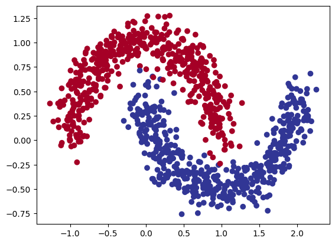

```python
# create graph from matplotlib
import matplotlib.pyplot as plt
plt.scatter(moon['X0'], moon['X1'], c=moon['label'], cmap=plt.cm.RdYlBu);
```

Now we can quickly see and understand what the moons are! Crescent-like shapes that form in 2 clearly separated ways. Our next step is to have our neural network figure out the boundaries of the blue crescent, and red crescent.

**Input and Output shape check!**

Important thing that stops us from progressing is if our inputand output shapes are wrong for our neural network. Our goal here is we want to input the shape of `X`, and then output the shape of `y`. So we'll quickly double check.

```python
# check X and y shapes
X.shape, y.shape
```

```
((1000, 2), (1000,))
```

Same length amount is seen on both with 1000, no need to adjust!

For our neural network, they will recieve an input of a one dimensional array with 2 values, and then have to output a singular value. Now there comes 3 fundamental steps to model building.

Creating a model, compiling a model, fitting a model. Let's start simple with one layer.

```python
# Set seed
tf.random.set_seed(35)

# Create model with sequential APi
model_1 = tf.keras.Sequential([
    tf.keras.layers.Dense(1)
])

# Compile model
model_1.compile(loss=tf.keras.losses.BinaryCrossentropy(),
                optimizer=tf.keras.optimizers.SGD(),
                metrics=['accuracy'])

# Fit the model
model_1.fit(X,y,epochs=5)
```

```
32/32 ━━━━━━━━━━━━━━━━━━━━ 1s 2ms/step - accuracy: 0.7106 - loss: 1.3096
32/32 ━━━━━━━━━━━━━━━━━━━━ 0s 2ms/step - accuracy: 0.8310 - loss: 0.3014
32/32 ━━━━━━━━━━━━━━━━━━━━ 0s 2ms/step - accuracy: 0.8261 - loss: 0.2906
32/32 ━━━━━━━━━━━━━━━━━━━━ 0s 2ms/step - accuracy: 0.8274 - loss: 0.2845
32/32 ━━━━━━━━━━━━━━━━━━━━ 0s 1ms/step - accuracy: 0.8354 - loss: 0.2800
```

```
<keras.src.callbacks.history.History at 0x1e6facd30d0>
```

Wow, already 83% accuracy without any substantial layers in our model! Let's see it visually on graph.

But to visualize it, we'll need to form a function named `plot_decision_boundary` which:

- Takes `X` and `y` data from the trained model.
- Creates a meshgrid off of `X` values.
- Makes predictions across meshgrid.
- Plots the predictions by drawing a line, separating where the different zones are.

```python
import numpy as np

def plot_decision_boundary(model, X, y):
    """
    Plots the decision boundary created by a model predicting on X.
    This function has been adapted from two phenomenal resources:
    1. CS231n - https://cs231n.github.io/neural-networks-case-study/
    2. Made with ML basics - https://github.com/GokuMohandas/MadeWithML/blob/main/notebooks/08_Neural_Networks.ipynb
    """
    # Define the axis boundaries of the plot and create a meshgrid
    x_min, x_max = X[:, 0].min() - 0.1, X[:, 0].max() + 0.1 # defines the boundaries of the min and max. They have a buffer of 0.1 from the min, and the max of each axis
    y_min, y_max = X[:, 1].min() - 0.1, X[:, 1].max() + 0.1
    xx, yy = np.meshgrid(np.linspace(x_min, x_max, 100), # linspace(start, stop, num) generates sequence of values that are evenly spaced from start to stop.
                         np.linspace(y_min, y_max, 100)) # create 100 evenly spaced points for xmin, xmax, ymin, and ymax.

    # Create X values (we're going to predict on all of these)
    x_in = np.c_[xx.ravel(), yy.ravel()] # stack 2D arrays together
    # .ravel > NumPy method that flattens a 2D array into 1D. The stack and flattening, allows the pair of coordinates (x and y) be used more efficiently by ML models.

    # Make predictions using the trained model
    y_pred = model.predict(x_in)

    # Check for multi-class
    if model.output_shape[-1] > 1: # checks the final dimension of the model's output chape, shape bigger than 1 = multi classification
        print('doing multiclass classification...')
        # We have to reshape our predictions to get then ready for plotting
        y_pred = np.argmax(y_pred, axis=1).reshape(xx.shape)
    else:
        print('doing binary classification...')
        y_pred = np.round(np.max(y_pred, axis=1)).reshape(xx.shape)

    # Plot decision boundary
    plt.contourf(xx, yy, y_pred, cmap=plt.cm.RdYlBu, alpha=0.7) # filled contour plot, to show x and y positions on the graph, along with the prediction. set alpha/transparency to 0.7 so we can see underneath overlapped dots
    plt.scatter(X[:, 0], X[:, 1], c=y, s=40, cmap=plt.cm.RdYlBu) # scatter plot of actual data, with x and y labels.
    plt.xlim(xx.min(), xx.max()) # last two, sets the max and min limits of the range in meshgrid/data
    plt.ylim(yy.min(), yy.max())
```

Let's try it out!

```
313/313 ━━━━━━━━━━━━━━━━━━━━ 0s 625us/step
doing binary classification...
```

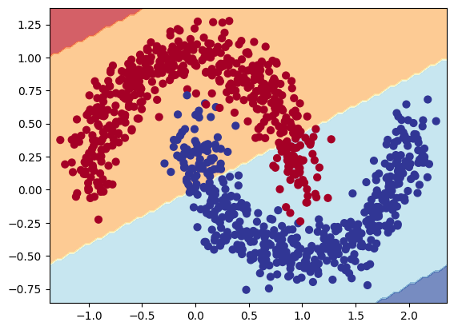

```python
# check out model prediction
plot_decision_boundary(model_1, X, y)
```

Now we have a first look at the modelling, but importantly we also have to separate them into train and test dataset. Its supposed to help us see how well the prediction line is on unfamiliar data.

We'll do a 80/20 train/test split.

```python
# create train test split, and see how long the dataset is, to successfully split it
len(X)
```

```
1000
```

```python
X_train, y_train = X[:800], y[:800]
X_test, y_test = X[800:], y[800:]

X_train.shape, y_test.shape
```

```
((800, 2), (200,))
```

Now let's create a model that uses Sigmoid, and implement those curves to the line, rather than linearity.

```python
# create model with sigmoid
tf.random.set_seed(35)

model_2 = tf.keras.Sequential([
    tf.keras.layers.Dense(1, activation=tf.keras.activations.sigmoid)
])

model_2.compile(loss=tf.keras.losses.BinaryCrossentropy(),
                optimizer=tf.keras.optimizers.SGD(),
                metrics=['accuracy'])

model_2.fit(X_train, y_train, epochs=100)
```

```
25/25 ━━━━━━━━━━━━━━━━━━━━ 0s 2ms/step - accuracy: 0.8279 - loss: 0.3929
25/25 ━━━━━━━━━━━━━━━━━━━━ 0s 2ms/step - accuracy: 0.8328 - loss: 0.3898
25/25 ━━━━━━━━━━━━━━━━━━━━ 0s 2ms/step - accuracy: 0.8329 - loss: 0.3868
25/25 ━━━━━━━━━━━━━━━━━━━━ 0s 2ms/step - accuracy: 0.8399 - loss: 0.3839
25/25 ━━━━━━━━━━━━━━━━━━━━ 0s 2ms/step - accuracy: 0.8427 - loss: 0.3812
25/25 ━━━━━━━━━━━━━━━━━━━━ 0s 2ms/step - accuracy: 0.8418 - loss: 0.3786
25/25 ━━━━━━━━━━━━━━━━━━━━ 0s 2ms/step - accuracy: 0.8429 - loss: 0.3761
25/25 ━━━━━━━━━━━━━━━━━━━━ 0s 2ms/step - accuracy: 0.8444 - loss: 0.3737
25/25 ━━━━━━━━━━━━━━━━━━━━ 0s 2ms/step - accuracy: 0.8472 - loss: 0.3714
25/25 ━━━━━━━━━━━━━━━━━━━━ 0s 2ms/step - accuracy: 0.8463 - loss: 0.3692
25/25 ━━━━━━━━━━━━━━━━━━━━ 0s 2ms/step - accuracy: 0.8468 - loss: 0.3671
25/25 ━━━━━━━━━━━━━━━━━━━━ 0s 2ms/step - accuracy: 0.8468 - loss: 0.3651
25/25 ━━━━━━━━━━━━━━━━━━━━ 0s 2ms/step - accuracy: 0.8468 - loss: 0.3631
25/25 ━━━━━━━━━━━━━━━━━━━━ 0s 2ms/step - accuracy: 0.8468 - loss: 0.3612
25/25 ━━━━━━━━━━━━━━━━━━━━ 0s 2ms/step - accuracy: 0.8468 - loss: 0.3594
25/25 ━━━━━━━━━━━━━━━━━━━━ 0s 2ms/step - accuracy: 0.8468 - loss: 0.3576
25/25 ━━━━━━━━━━━━━━━━━━━━ 0s 2ms/step - accuracy: 0.8473 - loss: 0.3559
25/25 ━━━━━━━━━━━━━━━━━━━━ 0s 2ms/step - accuracy: 0.8480 - loss: 0.3542
25/25 ━━━━━━━━━━━━━━━━━━━━ 0s 2ms/step - accuracy: 0.8480 - loss: 0.3526
25/25 ━━━━━━━━━━━━━━━━━━━━ 0s 2ms/step - accuracy: 0.8480 - loss: 0.3511
25/25 ━━━━━━━━━━━━━━━━━━━━ 0s 2ms/step - accuracy: 0.8480 - loss: 0.3496
25/25 ━━━━━━━━━━━━━━━━━━━━ 0s 2ms/step - accuracy: 0.8525 - loss: 0.3481
25/25 ━━━━━━━━━━━━━━━━━━━━ 0s 2ms/step - accuracy: 0.8525 - loss: 0.3467
25/25 ━━━━━━━━━━━━━━━━━━━━ 0s 2ms/step - accuracy: 0.8525 - loss: 0.3453
25/25 ━━━━━━━━━━━━━━━━━━━━ 0s 2ms/step - accuracy: 0.8525 - loss: 0.3439
25/25 ━━━━━━━━━━━━━━━━━━━━ 0s 2ms/step - accuracy: 0.8525 - loss: 0.3426
25/25 ━━━━━━━━━━━━━━━━━━━━ 0s 2ms/step - accuracy: 0.8525 - loss: 0.3414
25/25 ━━━━━━━━━━━━━━━━━━━━ 0s 2ms/step - accuracy: 0.8525 - loss: 0.3401
25/25 ━━━━━━━━━━━━━━━━━━━━ 0s 2ms/step - accuracy: 0.8532 - loss: 0.3389
25/25 ━━━━━━━━━━━━━━━━━━━━ 0s 2ms/step - accuracy: 0.8532 - loss: 0.3377
25/25 ━━━━━━━━━━━━━━━━━━━━ 0s 2ms/step - accuracy: 0.8536 - loss: 0.3366
25/25 ━━━━━━━━━━━━━━━━━━━━ 0s 2ms/step - accuracy: 0.8571 - loss: 0.3354
25/25 ━━━━━━━━━━━━━━━━━━━━ 0s 2ms/step - accuracy: 0.8571 - loss: 0.3343
25/25 ━━━━━━━━━━━━━━━━━━━━ 0s 2ms/step - accuracy: 0.8571 - loss: 0.3333
25/25 ━━━━━━━━━━━━━━━━━━━━ 0s 2ms/step - accuracy: 0.8571 - loss: 0.3322
25/25 ━━━━━━━━━━━━━━━━━━━━ 0s 2ms/step - accuracy: 0.8571 - loss: 0.3312
25/25 ━━━━━━━━━━━━━━━━━━━━ 0s 2ms/step - accuracy: 0.8571 - loss: 0.3302
25/25 ━━━━━━━━━━━━━━━━━━━━ 0s 2ms/step - accuracy: 0.8571 - loss: 0.3292
25/25 ━━━━━━━━━━━━━━━━━━━━ 0s 2ms/step - accuracy: 0.8571 - loss: 0.3283
25/25 ━━━━━━━━━━━━━━━━━━━━ 0s 2ms/step - accuracy: 0.8571 - loss: 0.3273
```

[output cut: 45 more lines]

```
25/25 ━━━━━━━━━━━━━━━━━━━━ 0s 2ms/step - accuracy: 0.8635 - loss: 0.2980
25/25 ━━━━━━━━━━━━━━━━━━━━ 0s 2ms/step - accuracy: 0.8660 - loss: 0.2976
25/25 ━━━━━━━━━━━━━━━━━━━━ 0s 2ms/step - accuracy: 0.8660 - loss: 0.2972
25/25 ━━━━━━━━━━━━━━━━━━━━ 0s 2ms/step - accuracy: 0.8660 - loss: 0.2967
25/25 ━━━━━━━━━━━━━━━━━━━━ 0s 2ms/step - accuracy: 0.8660 - loss: 0.2963
25/25 ━━━━━━━━━━━━━━━━━━━━ 0s 2ms/step - accuracy: 0.8660 - loss: 0.2959
25/25 ━━━━━━━━━━━━━━━━━━━━ 0s 2ms/step - accuracy: 0.8660 - loss: 0.2955
25/25 ━━━━━━━━━━━━━━━━━━━━ 0s 2ms/step - accuracy: 0.8660 - loss: 0.2951
25/25 ━━━━━━━━━━━━━━━━━━━━ 0s 2ms/step - accuracy: 0.8660 - loss: 0.2947
25/25 ━━━━━━━━━━━━━━━━━━━━ 0s 2ms/step - accuracy: 0.8660 - loss: 0.2943
25/25 ━━━━━━━━━━━━━━━━━━━━ 0s 2ms/step - accuracy: 0.8660 - loss: 0.2939
25/25 ━━━━━━━━━━━━━━━━━━━━ 0s 2ms/step - accuracy: 0.8668 - loss: 0.2935
25/25 ━━━━━━━━━━━━━━━━━━━━ 0s 2ms/step - accuracy: 0.8668 - loss: 0.2931
25/25 ━━━━━━━━━━━━━━━━━━━━ 0s 2ms/step - accuracy: 0.8668 - loss: 0.2927
25/25 ━━━━━━━━━━━━━━━━━━━━ 0s 2ms/step - accuracy: 0.8668 - loss: 0.2923
```

```
<keras.src.callbacks.history.History at 0x1e6fcabfa50>
```

Now we've achieved our goal of >85% accuracy. Before that, let's visualize the contents first.

```
313/313 ━━━━━━━━━━━━━━━━━━━━ 0s 617us/step
doing binary classification...
```

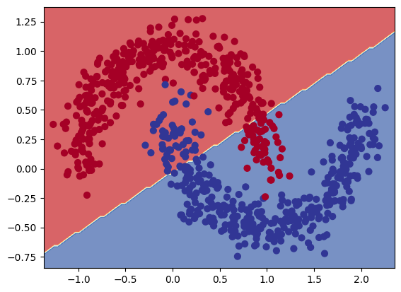

```python
plot_decision_boundary(model_2, X_train, y_train)
```

Hmmmm seems to still be a straight line, which I don't like to see. Let's add some complexity on the model layers, and use `ReLU`. Why `ReLU`? It helps introduce non-linearity into the model, allowing the neural network to identify non linear relationships. They also help mitigate vanishing gradients, as it's an issue where gradients become extremely small, and further training does not provide any significant difference in results.

We'll add 2 reLU layers with 4 neurons, and keep the sigmoid as the end

```python
# add to relu layers with 4 neurons
tf.random.set_seed(35)

model_3 = tf.keras.Sequential([
    tf.keras.layers.Dense(4, activation=tf.keras.activations.relu),
    tf.keras.layers.Dense(4, activation=tf.keras.activations.relu),
    tf.keras.layers.Dense(1, activation=tf.keras.activations.sigmoid)
])

model_3.compile(loss=tf.keras.losses.BinaryCrossentropy(),
                optimizer=tf.keras.optimizers.SGD(),
                metrics=['accuracy'])

model_3.fit(X_train, y_train, epochs=100)
```

```
25/25 ━━━━━━━━━━━━━━━━━━━━ 1s 2ms/step - accuracy: 0.4699 - loss: 0.7015
25/25 ━━━━━━━━━━━━━━━━━━━━ 0s 2ms/step - accuracy: 0.4623 - loss: 0.6883
25/25 ━━━━━━━━━━━━━━━━━━━━ 0s 2ms/step - accuracy: 0.4749 - loss: 0.6780
25/25 ━━━━━━━━━━━━━━━━━━━━ 0s 2ms/step - accuracy: 0.5173 - loss: 0.6692
25/25 ━━━━━━━━━━━━━━━━━━━━ 0s 2ms/step - accuracy: 0.5688 - loss: 0.6608
25/25 ━━━━━━━━━━━━━━━━━━━━ 0s 2ms/step - accuracy: 0.6143 - loss: 0.6527
25/25 ━━━━━━━━━━━━━━━━━━━━ 0s 2ms/step - accuracy: 0.6638 - loss: 0.6447
25/25 ━━━━━━━━━━━━━━━━━━━━ 0s 2ms/step - accuracy: 0.7061 - loss: 0.6367
25/25 ━━━━━━━━━━━━━━━━━━━━ 0s 2ms/step - accuracy: 0.7385 - loss: 0.6285
25/25 ━━━━━━━━━━━━━━━━━━━━ 0s 2ms/step - accuracy: 0.7458 - loss: 0.6200
25/25 ━━━━━━━━━━━━━━━━━━━━ 0s 2ms/step - accuracy: 0.7630 - loss: 0.6112
25/25 ━━━━━━━━━━━━━━━━━━━━ 0s 2ms/step - accuracy: 0.7891 - loss: 0.6022
25/25 ━━━━━━━━━━━━━━━━━━━━ 0s 2ms/step - accuracy: 0.7948 - loss: 0.5930
25/25 ━━━━━━━━━━━━━━━━━━━━ 0s 2ms/step - accuracy: 0.8082 - loss: 0.5837
25/25 ━━━━━━━━━━━━━━━━━━━━ 0s 2ms/step - accuracy: 0.8085 - loss: 0.5743
25/25 ━━━━━━━━━━━━━━━━━━━━ 0s 2ms/step - accuracy: 0.8127 - loss: 0.5649
25/25 ━━━━━━━━━━━━━━━━━━━━ 0s 2ms/step - accuracy: 0.8206 - loss: 0.5555
25/25 ━━━━━━━━━━━━━━━━━━━━ 0s 2ms/step - accuracy: 0.8216 - loss: 0.5463
25/25 ━━━━━━━━━━━━━━━━━━━━ 0s 2ms/step - accuracy: 0.8224 - loss: 0.5372
25/25 ━━━━━━━━━━━━━━━━━━━━ 0s 2ms/step - accuracy: 0.8228 - loss: 0.5284
25/25 ━━━━━━━━━━━━━━━━━━━━ 0s 2ms/step - accuracy: 0.8241 - loss: 0.5197
25/25 ━━━━━━━━━━━━━━━━━━━━ 0s 2ms/step - accuracy: 0.8312 - loss: 0.5113
25/25 ━━━━━━━━━━━━━━━━━━━━ 0s 2ms/step - accuracy: 0.8317 - loss: 0.5030
25/25 ━━━━━━━━━━━━━━━━━━━━ 0s 2ms/step - accuracy: 0.8370 - loss: 0.4948
25/25 ━━━━━━━━━━━━━━━━━━━━ 0s 2ms/step - accuracy: 0.8376 - loss: 0.4869
25/25 ━━━━━━━━━━━━━━━━━━━━ 0s 2ms/step - accuracy: 0.8401 - loss: 0.4791
25/25 ━━━━━━━━━━━━━━━━━━━━ 0s 2ms/step - accuracy: 0.8439 - loss: 0.4715
25/25 ━━━━━━━━━━━━━━━━━━━━ 0s 2ms/step - accuracy: 0.8448 - loss: 0.4640
25/25 ━━━━━━━━━━━━━━━━━━━━ 0s 2ms/step - accuracy: 0.8454 - loss: 0.4568
25/25 ━━━━━━━━━━━━━━━━━━━━ 0s 2ms/step - accuracy: 0.8472 - loss: 0.4498
25/25 ━━━━━━━━━━━━━━━━━━━━ 0s 2ms/step - accuracy: 0.8587 - loss: 0.4429
25/25 ━━━━━━━━━━━━━━━━━━━━ 0s 2ms/step - accuracy: 0.8612 - loss: 0.4362
25/25 ━━━━━━━━━━━━━━━━━━━━ 0s 2ms/step - accuracy: 0.8623 - loss: 0.4297
25/25 ━━━━━━━━━━━━━━━━━━━━ 0s 2ms/step - accuracy: 0.8594 - loss: 0.4233
25/25 ━━━━━━━━━━━━━━━━━━━━ 0s 2ms/step - accuracy: 0.8594 - loss: 0.4171
25/25 ━━━━━━━━━━━━━━━━━━━━ 0s 2ms/step - accuracy: 0.8607 - loss: 0.4110
25/25 ━━━━━━━━━━━━━━━━━━━━ 0s 2ms/step - accuracy: 0.8604 - loss: 0.4050
25/25 ━━━━━━━━━━━━━━━━━━━━ 0s 2ms/step - accuracy: 0.8612 - loss: 0.3991
25/25 ━━━━━━━━━━━━━━━━━━━━ 0s 2ms/step - accuracy: 0.8691 - loss: 0.3933
25/25 ━━━━━━━━━━━━━━━━━━━━ 0s 2ms/step - accuracy: 0.8727 - loss: 0.3876
```

[output cut: 45 more lines]

```
25/25 ━━━━━━━━━━━━━━━━━━━━ 0s 2ms/step - accuracy: 0.9034 - loss: 0.2492
25/25 ━━━━━━━━━━━━━━━━━━━━ 0s 2ms/step - accuracy: 0.9034 - loss: 0.2481
25/25 ━━━━━━━━━━━━━━━━━━━━ 0s 2ms/step - accuracy: 0.9034 - loss: 0.2470
25/25 ━━━━━━━━━━━━━━━━━━━━ 0s 2ms/step - accuracy: 0.9034 - loss: 0.2460
25/25 ━━━━━━━━━━━━━━━━━━━━ 0s 2ms/step - accuracy: 0.9037 - loss: 0.2451
25/25 ━━━━━━━━━━━━━━━━━━━━ 0s 2ms/step - accuracy: 0.9037 - loss: 0.2442
25/25 ━━━━━━━━━━━━━━━━━━━━ 0s 2ms/step - accuracy: 0.9037 - loss: 0.2433
25/25 ━━━━━━━━━━━━━━━━━━━━ 0s 2ms/step - accuracy: 0.9037 - loss: 0.2424
25/25 ━━━━━━━━━━━━━━━━━━━━ 0s 2ms/step - accuracy: 0.9037 - loss: 0.2416
25/25 ━━━━━━━━━━━━━━━━━━━━ 0s 2ms/step - accuracy: 0.9037 - loss: 0.2408
25/25 ━━━━━━━━━━━━━━━━━━━━ 0s 2ms/step - accuracy: 0.9018 - loss: 0.2400
25/25 ━━━━━━━━━━━━━━━━━━━━ 0s 2ms/step - accuracy: 0.9018 - loss: 0.2393
25/25 ━━━━━━━━━━━━━━━━━━━━ 0s 2ms/step - accuracy: 0.9018 - loss: 0.2386
25/25 ━━━━━━━━━━━━━━━━━━━━ 0s 2ms/step - accuracy: 0.9018 - loss: 0.2379
25/25 ━━━━━━━━━━━━━━━━━━━━ 0s 2ms/step - accuracy: 0.9018 - loss: 0.2372
```

```
<keras.src.callbacks.history.History at 0x1e6fd05fa50>
```

Results looking better and better, and we've achieved our goal once again! Let's look at the graph!

```
313/313 ━━━━━━━━━━━━━━━━━━━━ 0s 715us/step
doing binary classification...
```

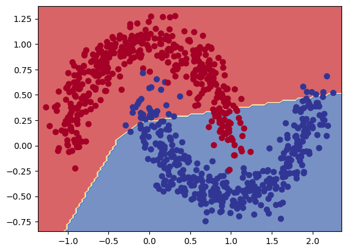

```python
plot_decision_boundary(model_3, X_train, y_train)
```

Bingo! Non-linearity :)

Let's also see how well it overlays on the test dataset

```
313/313 ━━━━━━━━━━━━━━━━━━━━ 0s 699us/step
doing binary classification...
```

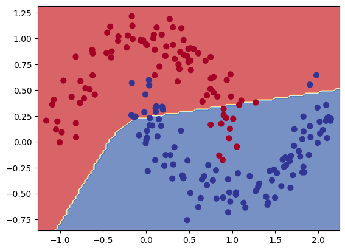

```python
plot_decision_boundary(model_3, X_test, y_test)
```

### 4. Create a function to visualize multiple image predictions, using `fashion MNIST`, then plot 3 different images with prediction labels at the same time.

Hint: see the [classification tutorial in the TensorFlow documentation](https://www.tensorflow.org/tutorials/keras/classification) for ideas.

Let's firstly import the `fashion MNIST` dataset into our workbook.

```python
# import fashion MNIST
from tensorflow.keras.datasets import fashion_mnist

# sort into train and test datasets, which have already been prepeared for us
(train_data, train_labels), (test_data, test_labels) = fashion_mnist.load_data()

# lets see the first result
print(f'Training data:\n{train_data[0]}\n')
print(f'Train label: {train_labels[0]}')
```

```
Training data:
[[  0   0   0   0   0   0   0   0   0   0   0   0   0   0   0   0   0   0
    0   0   0   0   0   0   0   0   0   0]
 [  0   0   0   0   0   0   0   0   0   0   0   0   0   0   0   0   0   0
    0   0   0   0   0   0   0   0   0   0]
 [  0   0   0   0   0   0   0   0   0   0   0   0   0   0   0   0   0   0
    0   0   0   0   0   0   0   0   0   0]
 [  0   0   0   0   0   0   0   0   0   0   0   0   1   0   0  13  73   0
    0   1   4   0   0   0   0   1   1   0]
 [  0   0   0   0   0   0   0   0   0   0   0   0   3   0  36 136 127  62
   54   0   0   0   1   3   4   0   0   3]
 [  0   0   0   0   0   0   0   0   0   0   0   0   6   0 102 204 176 134
  144 123  23   0   0   0   0  12  10   0]
 [  0   0   0   0   0   0   0   0   0   0   0   0   0   0 155 236 207 178
  107 156 161 109  64  23  77 130  72  15]
 [  0   0   0   0   0   0   0   0   0   0   0   1   0  69 207 223 218 216
  216 163 127 121 122 146 141  88 172  66]
 [  0   0   0   0   0   0   0   0   0   1   1   1   0 200 232 232 233 229
  223 223 215 213 164 127 123 196 229   0]
 [  0   0   0   0   0   0   0   0   0   0   0   0   0 183 225 216 223 228
  235 227 224 222 224 221 223 245 173   0]
 [  0   0   0   0   0   0   0   0   0   0   0   0   0 193 228 218 213 198
  180 212 210 211 213 223 220 243 202   0]
 [  0   0   0   0   0   0   0   0   0   1   3   0  12 219 220 212 218 192
  169 227 208 218 224 212 226 197 209  52]
 [  0   0   0   0   0   0   0   0   0   0   6   0  99 244 222 220 218 203
  198 221 215 213 222 220 245 119 167  56]
 [  0   0   0   0   0   0   0   0   0   4   0   0  55 236 228 230 228 240
  232 213 218 223 234 217 217 209  92   0]
 [  0   0   1   4   6   7   2   0   0   0   0   0 237 226 217 223 222 219
  222 221 216 223 229 215 218 255  77   0]
 [  0   3   0   0   0   0   0   0   0  62 145 204 228 207 213 221 218 208
  211 218 224 223 219 215 224 244 159   0]
 [  0   0   0   0  18  44  82 107 189 228 220 222 217 226 200 205 211 230
  224 234 176 188 250 248 233 238 215   0]
 [  0  57 187 208 224 221 224 208 204 214 208 209 200 159 245 193 206 223
  255 255 221 234 221 211 220 232 246   0]
 [  3 202 228 224 221 211 211 214 205 205 205 220 240  80 150 255 229 221
  188 154 191 210 204 209 222 228 225   0]
 [ 98 233 198 210 222 229 229 234 249 220 194 215 217 241  65  73 106 117
  168 219 221 215 217 223 223 224 229  29]
 [ 75 204 212 204 193 205 211 225 216 185 197 206 198 213 240 195 227 245
  239 223 218 212 209 222 220 221 230  67]
 [ 48 203 183 194 213 197 185 190 194 192 202 214 219 221 220 236 225 216
  199 206 186 181 177 172 181 205 206 115]
 [  0 122 219 193 179 171 183 196 204 210 213 207 211 210 200 196 194 191
  195 191 198 192 176 156 167 177 210  92]
 [  0   0  74 189 212 191 175 172 175 181 185 188 189 188 193 198 204 209
  210 210 211 188 188 194 192 216 170   0]
 [  2   0   0   0  66 200 222 237 239 242 246 243 244 221 220 193 191 179
  182 182 181 176 166 168  99  58   0   0]
 [  0   0   0   0   0   0   0  40  61  44  72  41  35   0   0   0   0   0
    0   0   0   0   0   0   0   0   0   0]
 [  0   0   0   0   0   0   0   0   0   0   0   0   0   0   0   0   0   0
    0   0   0   0   0   0   0   0   0   0]
 [  0   0   0   0   0   0   0   0   0   0   0   0   0   0   0   0   0   0
    0   0   0   0   0   0   0   0   0   0]]

Train label: 9
```

Now we see the resulting data of the clothing on index 0, and what label it is attached to. Let's have better visual on the data given, aka looking at the shape of the data given

```python
# check shape of dataset
train_data.shape, test_data.shape, train_labels.shape, test_labels.shape
```

```
((60000, 28, 28), (10000, 28, 28), (60000,), (10000,))
```

We have quite the number of test data, when comparing as ratio to train data. A little atypical to the 80/20 split that most ML models use.

We also see the data's shape is 28x28, likely we're dealing with a 28 by 28 pixel image, thats meant to represent a certain item of clothing. Let's check what kind of numerical value is there by its min and max.

```python
# look at min and max value in train/test data
train_data.min(), train_data.max(), test_data.min(), test_data.max()
```

```
(np.uint8(0), np.uint8(255), np.uint8(0), np.uint8(255))
```

Data value shows a range from 0 to 255. That kind of number is indicative to colour or alpha value. Often 0 means no brightness/colour, and 255 is full brightness/colour.

Let's have a look at the resulting image for index[0] image.

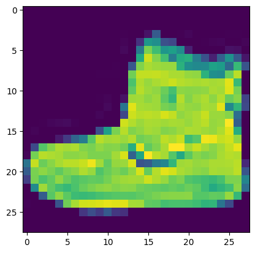

```python
import matplotlib.pyplot as plt

plt.imshow(train_data[0])
```

Image appears to show a shoe or a boot!

What about our labels? So far index[0] provides a numerical value for it only. Fortunately the github page from where this dataset came from, has the name of all item clothing thats present in this dataset, and we'll be using it.

`class_names = ['T-shirt/top','Trouse','Pullover','Dress','Coat','Sandal','Shirt','Sneaker','Bag','Ankle boot']`

Note these prepared datasets, ready for modelling do not exist in real world problems. We'll have to figure alot of it out on the way to the end product, and do a lot of data cleaning as well.

```python
class_names = ['T-shirt/top','Trouse','Pullover','Dress','Coat','Sandal','Shirt','Sneaker','Bag','Ankle boot']

# how many classes are we dealing with?
len(class_names)
```

```
10
```

### 5. Recreate [TensorFlow's softmax activation function](https://en.wikipedia.org/wiki/Softmax_function) in your own code, and that it can accept/return tensors.

Next step of the agenda, build a ML model for the dataset, and present it visually with its predictions as well!

There's a few changes needed to be made if we were to use the previous model, as the model is binary classification use, rather than multi classification (which is this data problem):

- **Input shape**: Our shape is 28 by 28 tensors, (each pixel fits a tensor). We will have to squish it down to one dimensional 784 tensors.
- **Output shape**: Will be 10, as we got 10 categories the model has to predict from.
  - Change output activation from `sigmoid` to `softmax`. The goal is to predict the likelihood the image is to be a category from 0 to 1. Then the model picks the category thats most likely to be the picture.
- **Loss function**: Change the binary loss function to multiclass loss function.
  - Our labels are not one hot encoded, but numerical. So we'll use `tf.keras.losses.SparseCategoricalCrossentropy`.

We will also treat the test data as our validation dataset.

But before we do that, we'll have to somehow create our own softmax activation function for this particular exercise. Seems easy on paper as its just probability, but I honestly have zero fuckin clue how to start creating this function.

#### So what does softmax **actually do?**: Let's ask Deepseek/ChatGPT

1. **Input**: We get an array of raw scores, aka our tensors into softmax `[2.0, 1.0, -2.0]`
2. **Exponentiation**: We apply exponentiation on `Euler's number`, with the help of the raw scores. So all values stay positive, and further accentuate the values that have higher scores.
   - `Exponents - Maximum raw score` is donw to ensure numerical stability, and not get values so out of proportion.
   - Euler's number = ~2.718 `[e^ 2.0, e^ 1.0, e^ -2.0]` = `[7.39, 2.71, 0.135]` We essentially use Euler's number, and exponentiate it with every raw score.
3. **Normalization**: Sum up all values from step 2, then divide it on each exponentiated raw score. This keeps all sum of scores = 1, making them interpretable as probabilities, as they essentially all add up to 100%.
4. **Output**: Shat out our probability list for every category in our data.

Let's go ahead and create a function based on what I've just learnt.

```python
# create the softmax function on my own

def softmax(logits): # Step 1: Input our array of raw scores
    """Compute softmax from a given array of logits"""

    # Step 2: Exponentiate with Euler's number, while subtracting from max value to ensure numerical stability
    max_logits = np.max(logits)
    exp_value = np.exp(logits-max_logits)

    # Step 3: Normalization from dividing the sum of all exponentiated values
    probabilities = exp_value/np.sum(exp_value)

    # Step 4: Output probabilities
    return probabilities
```

The code above actually doesn't work with our model. Because we are using TensorFlow, it can only implement using Tensor code, but we used NumPy code instead for the softmax function.

Therefore we'll need to overhaul it and fit it with Tensor code instead.

#### Create softmax function, but its TensorFlow friendly:

```python
# create TensorFlow friendly softmax function

def custom_softmax(logits): # Step 1: Input our array of raw scores
    """Compute softmax from a given array of logits"""

    # Step 2: Exponentiate with Euler's number, while subtracting from max value to ensure numerical stability
    max_logits = tf.reduce_max(logits, axis=-1, keepdims=True) # axis=-1 > apply it all the way till the last tensor (to help us find the max value)
    exp_value = tf.exp(logits-max_logits)

    # Step 3: Normalization from dividing the sum of all exponentiated values
    probabilities = exp_value/tf.reduce_sum(exp_value, axis=-1, keepdims=True) # keepdims=True > we need to keep it the same shape to the logits, or else we'll break the model

    # Step 4: Output probabilities
    return probabilities
```

Let's test out the function

```python
logits = np.array([2.0, 1.0, -2.0])
print(custom_softmax(logits))
```

```
tf.Tensor([0.72139918 0.26538793 0.01321289], shape=(3,), dtype=float64)
```

```python
# setup multi categorical model for the clothing MNIST data
tf.random.set_seed(35)

# model layers
model_4 = tf.keras.Sequential([
    tf.keras.layers.Flatten(input_shape=(28,28)), # input layer of 28x28, and flatten it for the model
    tf.keras.layers.Dense(4, activation='relu'),
    tf.keras.layers.Dense(4, activation='relu'),
    tf.keras.layers.Dense(10), # output layer, 10 neurons representing 10 categories. We will add our custom softmax function as well
    tf.keras.layers.Lambda(custom_softmax)
])

# compile the model
model_4.compile(loss=tf.keras.losses.SparseCategoricalCrossentropy(),
                optimizer=tf.keras.optimizers.Adam(),
                metrics=['accuracy'])

# fit the model
model_4.fit(train_data, train_labels, epochs=10, validation_data=(test_data, test_labels))
```

```
1875/1875 ━━━━━━━━━━━━━━━━━━━━ 3s 1ms/step - accuracy: 0.1253 - loss: 2.3057 - val_accuracy: 0.1706 - val_loss: 2.1320
1875/1875 ━━━━━━━━━━━━━━━━━━━━ 3s 1ms/step - accuracy: 0.1823 - loss: 2.0976 - val_accuracy: 0.2782 - val_loss: 1.7346
1875/1875 ━━━━━━━━━━━━━━━━━━━━ 3s 1ms/step - accuracy: 0.2874 - loss: 1.7373 - val_accuracy: 0.3117 - val_loss: 1.6579
1875/1875 ━━━━━━━━━━━━━━━━━━━━ 2s 1ms/step - accuracy: 0.3297 - loss: 1.6290 - val_accuracy: 0.3451 - val_loss: 1.5703
1875/1875 ━━━━━━━━━━━━━━━━━━━━ 2s 1ms/step - accuracy: 0.3445 - loss: 1.5779 - val_accuracy: 0.3656 - val_loss: 1.5358
1875/1875 ━━━━━━━━━━━━━━━━━━━━ 3s 1ms/step - accuracy: 0.3723 - loss: 1.5108 - val_accuracy: 0.3982 - val_loss: 1.4378
1875/1875 ━━━━━━━━━━━━━━━━━━━━ 4s 2ms/step - accuracy: 0.3942 - loss: 1.4514 - val_accuracy: 0.4108 - val_loss: 1.4090
1875/1875 ━━━━━━━━━━━━━━━━━━━━ 4s 2ms/step - accuracy: 0.4031 - loss: 1.4250 - val_accuracy: 0.4139 - val_loss: 1.4201
1875/1875 ━━━━━━━━━━━━━━━━━━━━ 4s 1ms/step - accuracy: 0.4078 - loss: 1.4103 - val_accuracy: 0.4078 - val_loss: 1.4126
1875/1875 ━━━━━━━━━━━━━━━━━━━━ 3s 1ms/step - accuracy: 0.4111 - loss: 1.3994 - val_accuracy: 0.3975 - val_loss: 1.4238
```

```
<keras.src.callbacks.history.History at 0x1e6f8246f50>
```

Not the best results, getting about 39% accuracy. So let's fix that and get >88% accuracy!

### 6. Train model to get +88% accuracy on the fashion MNIST test set. Plot a confusion matrix to see the results after.

#### Normalize our data:

One way to increase accuracy is normalize our data. Specifically getting the data to be in the ranges of 0 to 1, as neural networks learn well from data in that range.

Luckily our data is simple, and we know the max value of the data is 255 from before (and its also image colour values). So we can simply divide the data by 255.

```python
# normalize data to between 0 and 1
train_data = train_data/255.0
test_data = test_data/255.0

train_data.min(), test_data.max()
```

```
(np.float64(0.0), np.float64(1.0))
```

If we ever need the original dataset, we can multiply it to 255, to get the old data!

Let's retry the model from above again

```python
# retry model from above with normalized data
model_4.fit(train_data, train_labels, epochs=10, validation_data=(test_data, test_labels))
```

```
1875/1875 ━━━━━━━━━━━━━━━━━━━━ 3s 1ms/step - accuracy: 0.2911 - loss: 1.7633 - val_accuracy: 0.4307 - val_loss: 1.4141
1875/1875 ━━━━━━━━━━━━━━━━━━━━ 2s 1ms/step - accuracy: 0.4601 - loss: 1.3765 - val_accuracy: 0.5147 - val_loss: 1.2294
1875/1875 ━━━━━━━━━━━━━━━━━━━━ 2s 1ms/step - accuracy: 0.5291 - loss: 1.1585 - val_accuracy: 0.5604 - val_loss: 1.0415
1875/1875 ━━━━━━━━━━━━━━━━━━━━ 2s 1ms/step - accuracy: 0.5813 - loss: 1.0036 - val_accuracy: 0.6413 - val_loss: 0.8971
1875/1875 ━━━━━━━━━━━━━━━━━━━━ 2s 1ms/step - accuracy: 0.6517 - loss: 0.8558 - val_accuracy: 0.6628 - val_loss: 0.8279
1875/1875 ━━━━━━━━━━━━━━━━━━━━ 2s 1ms/step - accuracy: 0.6675 - loss: 0.8047 - val_accuracy: 0.6797 - val_loss: 0.8048
1875/1875 ━━━━━━━━━━━━━━━━━━━━ 2s 1ms/step - accuracy: 0.6794 - loss: 0.7843 - val_accuracy: 0.6915 - val_loss: 0.7936
1875/1875 ━━━━━━━━━━━━━━━━━━━━ 2s 1ms/step - accuracy: 0.6863 - loss: 0.7727 - val_accuracy: 0.6964 - val_loss: 0.7872
1875/1875 ━━━━━━━━━━━━━━━━━━━━ 2s 1ms/step - accuracy: 0.6910 - loss: 0.7646 - val_accuracy: 0.6995 - val_loss: 0.7837
1875/1875 ━━━━━━━━━━━━━━━━━━━━ 2s 1ms/step - accuracy: 0.6945 - loss: 0.7570 - val_accuracy: 0.7004 - val_loss: 0.7799
```

```
<keras.src.callbacks.history.History at 0x1e6fe9e02d0>
```

Somewhat of an improvement made to 70%! Let's see what else we could also do.

#### Finding ideal learning rate of `Adam`

One thing we could do, is find the ideal learning rate of `Adam`, our optimizer. We so far don't know what that value is. But we can find it through creating a mathematical operator and function, that allows us to exponentially increase the learning rate of `Adam`, and then see the historic results through storing it in a variable.

```python
# Create a model that increases learning rate exponentially, and then storing results in a variable
tf.random.set_seed(35)

model_5 = tf.keras.Sequential([
    tf.keras.layers.Flatten(input_shape=(28,28)),
    tf.keras.layers.Dense(4, activation='relu'),
    tf.keras.layers.Dense(4, activation='relu'),
    tf.keras.layers.Dense(10),
    tf.keras.layers.Lambda(custom_softmax)
])

model_5.compile(loss=tf.keras.losses.SparseCategoricalCrossentropy(),
                optimizer=tf.keras.optimizers.Adam(),
                metrics=['accuracy'])

# create learning rate scheduler, updating Adam's learning rate constantly
lr_scheduler = tf.keras.callbacks.LearningRateScheduler(lambda epoch: 1e-3 * 10 ** (epoch/20)) # form mathematical operation, for exponential increase in learning rate

find_learningrate = model_5.fit(train_data, train_labels, epochs=40, validation_data=(test_data, test_labels), callbacks=[lr_scheduler])
```

```
1875/1875 ━━━━━━━━━━━━━━━━━━━━ 3s 1ms/step - accuracy: 0.3149 - loss: 1.7842 - val_accuracy: 0.5463 - val_loss: 1.1434 - learning_rate: 0.0010
1875/1875 ━━━━━━━━━━━━━━━━━━━━ 2s 1ms/step - accuracy: 0.5598 - loss: 1.0564 - val_accuracy: 0.5895 - val_loss: 0.9591 - learning_rate: 0.0011
1875/1875 ━━━━━━━━━━━━━━━━━━━━ 2s 1ms/step - accuracy: 0.6099 - loss: 0.9104 - val_accuracy: 0.6926 - val_loss: 0.8187 - learning_rate: 0.0013
1875/1875 ━━━━━━━━━━━━━━━━━━━━ 3s 1ms/step - accuracy: 0.7218 - loss: 0.7670 - val_accuracy: 0.7525 - val_loss: 0.7357 - learning_rate: 0.0014
1875/1875 ━━━━━━━━━━━━━━━━━━━━ 3s 2ms/step - accuracy: 0.7565 - loss: 0.6972 - val_accuracy: 0.7606 - val_loss: 0.7083 - learning_rate: 0.0016
1875/1875 ━━━━━━━━━━━━━━━━━━━━ 3s 1ms/step - accuracy: 0.7654 - loss: 0.6688 - val_accuracy: 0.7639 - val_loss: 0.6907 - learning_rate: 0.0018
1875/1875 ━━━━━━━━━━━━━━━━━━━━ 3s 1ms/step - accuracy: 0.7716 - loss: 0.6519 - val_accuracy: 0.7684 - val_loss: 0.6806 - learning_rate: 0.0020
1875/1875 ━━━━━━━━━━━━━━━━━━━━ 2s 1ms/step - accuracy: 0.7724 - loss: 0.6403 - val_accuracy: 0.7694 - val_loss: 0.6749 - learning_rate: 0.0022
1875/1875 ━━━━━━━━━━━━━━━━━━━━ 2s 1ms/step - accuracy: 0.7742 - loss: 0.6321 - val_accuracy: 0.7722 - val_loss: 0.6670 - learning_rate: 0.0025
1875/1875 ━━━━━━━━━━━━━━━━━━━━ 2s 1ms/step - accuracy: 0.7751 - loss: 0.6266 - val_accuracy: 0.7717 - val_loss: 0.6632 - learning_rate: 0.0028
1875/1875 ━━━━━━━━━━━━━━━━━━━━ 2s 1ms/step - accuracy: 0.7769 - loss: 0.6215 - val_accuracy: 0.7717 - val_loss: 0.6593 - learning_rate: 0.0032
1875/1875 ━━━━━━━━━━━━━━━━━━━━ 2s 1ms/step - accuracy: 0.7775 - loss: 0.6178 - val_accuracy: 0.7720 - val_loss: 0.6561 - learning_rate: 0.0035
1875/1875 ━━━━━━━━━━━━━━━━━━━━ 2s 1ms/step - accuracy: 0.7769 - loss: 0.6171 - val_accuracy: 0.7721 - val_loss: 0.6490 - learning_rate: 0.0040
1875/1875 ━━━━━━━━━━━━━━━━━━━━ 2s 1ms/step - accuracy: 0.7779 - loss: 0.6169 - val_accuracy: 0.7724 - val_loss: 0.6492 - learning_rate: 0.0045
1875/1875 ━━━━━━━━━━━━━━━━━━━━ 3s 1ms/step - accuracy: 0.7776 - loss: 0.6169 - val_accuracy: 0.7726 - val_loss: 0.6507 - learning_rate: 0.0050
1875/1875 ━━━━━━━━━━━━━━━━━━━━ 2s 1ms/step - accuracy: 0.7772 - loss: 0.6170 - val_accuracy: 0.7737 - val_loss: 0.6587 - learning_rate: 0.0056
1875/1875 ━━━━━━━━━━━━━━━━━━━━ 2s 1ms/step - accuracy: 0.7765 - loss: 0.6194 - val_accuracy: 0.7687 - val_loss: 0.6666 - learning_rate: 0.0063
1875/1875 ━━━━━━━━━━━━━━━━━━━━ 2s 1ms/step - accuracy: 0.7760 - loss: 0.6224 - val_accuracy: 0.7691 - val_loss: 0.6606 - learning_rate: 0.0071
1875/1875 ━━━━━━━━━━━━━━━━━━━━ 3s 1ms/step - accuracy: 0.7747 - loss: 0.6258 - val_accuracy: 0.7743 - val_loss: 0.6582 - learning_rate: 0.0079
1875/1875 ━━━━━━━━━━━━━━━━━━━━ 3s 2ms/step - accuracy: 0.7727 - loss: 0.6298 - val_accuracy: 0.7729 - val_loss: 0.6507 - learning_rate: 0.0089
1875/1875 ━━━━━━━━━━━━━━━━━━━━ 3s 1ms/step - accuracy: 0.7729 - loss: 0.6331 - val_accuracy: 0.7683 - val_loss: 0.6573 - learning_rate: 0.0100
1875/1875 ━━━━━━━━━━━━━━━━━━━━ 3s 1ms/step - accuracy: 0.7719 - loss: 0.6345 - val_accuracy: 0.7622 - val_loss: 0.6607 - learning_rate: 0.0112
1875/1875 ━━━━━━━━━━━━━━━━━━━━ 2s 1ms/step - accuracy: 0.7697 - loss: 0.6410 - val_accuracy: 0.7612 - val_loss: 0.6638 - learning_rate: 0.0126
1875/1875 ━━━━━━━━━━━━━━━━━━━━ 3s 1ms/step - accuracy: 0.7670 - loss: 0.6473 - val_accuracy: 0.7543 - val_loss: 0.6786 - learning_rate: 0.0141
1875/1875 ━━━━━━━━━━━━━━━━━━━━ 3s 1ms/step - accuracy: 0.7659 - loss: 0.6532 - val_accuracy: 0.7579 - val_loss: 0.7074 - learning_rate: 0.0158
1875/1875 ━━━━━━━━━━━━━━━━━━━━ 2s 1ms/step - accuracy: 0.7639 - loss: 0.6593 - val_accuracy: 0.7547 - val_loss: 0.7037 - learning_rate: 0.0178
1875/1875 ━━━━━━━━━━━━━━━━━━━━ 2s 1ms/step - accuracy: 0.7578 - loss: 0.6705 - val_accuracy: 0.7515 - val_loss: 0.6999 - learning_rate: 0.0200
1875/1875 ━━━━━━━━━━━━━━━━━━━━ 3s 1ms/step - accuracy: 0.7564 - loss: 0.6802 - val_accuracy: 0.7271 - val_loss: 0.7344 - learning_rate: 0.0224
1875/1875 ━━━━━━━━━━━━━━━━━━━━ 3s 1ms/step - accuracy: 0.7487 - loss: 0.7007 - val_accuracy: 0.7266 - val_loss: 0.7478 - learning_rate: 0.0251
1875/1875 ━━━━━━━━━━━━━━━━━━━━ 2s 1ms/step - accuracy: 0.7443 - loss: 0.7075 - val_accuracy: 0.7296 - val_loss: 0.7483 - learning_rate: 0.0282
1875/1875 ━━━━━━━━━━━━━━━━━━━━ 2s 1ms/step - accuracy: 0.7300 - loss: 0.7376 - val_accuracy: 0.7396 - val_loss: 0.7215 - learning_rate: 0.0316
1875/1875 ━━━━━━━━━━━━━━━━━━━━ 2s 1ms/step - accuracy: 0.7173 - loss: 0.7809 - val_accuracy: 0.7392 - val_loss: 0.7261 - learning_rate: 0.0355
1875/1875 ━━━━━━━━━━━━━━━━━━━━ 2s 1ms/step - accuracy: 0.7028 - loss: 0.8085 - val_accuracy: 0.7276 - val_loss: 0.8030 - learning_rate: 0.0398
1875/1875 ━━━━━━━━━━━━━━━━━━━━ 2s 1ms/step - accuracy: 0.6855 - loss: 0.8705 - val_accuracy: 0.5819 - val_loss: 1.0189 - learning_rate: 0.0447
1875/1875 ━━━━━━━━━━━━━━━━━━━━ 2s 1ms/step - accuracy: 0.5650 - loss: 1.1058 - val_accuracy: 0.5678 - val_loss: 1.0581 - learning_rate: 0.0501
1875/1875 ━━━━━━━━━━━━━━━━━━━━ 2s 1ms/step - accuracy: 0.5266 - loss: 1.1632 - val_accuracy: 0.5167 - val_loss: 1.1528 - learning_rate: 0.0562
1875/1875 ━━━━━━━━━━━━━━━━━━━━ 2s 1ms/step - accuracy: 0.2261 - loss: 2.0192 - val_accuracy: 0.1979 - val_loss: 1.8222 - learning_rate: 0.0631
1875/1875 ━━━━━━━━━━━━━━━━━━━━ 2s 1ms/step - accuracy: 0.1955 - loss: 1.8195 - val_accuracy: 0.1996 - val_loss: 1.7720 - learning_rate: 0.0708
1875/1875 ━━━━━━━━━━━━━━━━━━━━ 2s 1ms/step - accuracy: 0.1938 - loss: 1.8214 - val_accuracy: 0.2000 - val_loss: 1.7923 - learning_rate: 0.0794
1875/1875 ━━━━━━━━━━━━━━━━━━━━ 2s 1ms/step - accuracy: 0.1943 - loss: 1.8272 - val_accuracy: 0.1000 - val_loss: 6.1637 - learning_rate: 0.0891
```

Now let's see the ideal training rate, by visualizing our variable, `find_learningrate`.

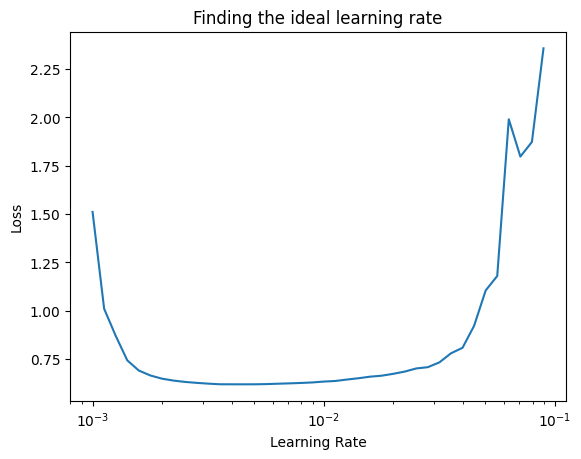

```python
# plot ideal rate curve
import numpy as np
import matplotlib.pyplot as plt

lrs = 1e-3 * (10 ** (np.arange(40)/20)) # recreating learning rate from model, to input for graph and have it scale correctly
plt.semilogx(lrs, find_learningrate.history['loss'])
plt.xlabel('Learning Rate')
plt.ylabel('Loss')
plt.title('Finding the ideal learning rate');
```

```python
tf.random.set_seed(35)

model_6 = tf.keras.Sequential([
    tf.keras.layers.Flatten(input_shape=(28,28)),
    tf.keras.layers.Dense(4, activation='relu'),
    tf.keras.layers.Dense(4, activation='relu'),
    tf.keras.layers.Dense(10),
    tf.keras.layers.Lambda(custom_softmax)
])

model_6.compile(loss=tf.keras.losses.SparseCategoricalCrossentropy,
                optimizer=tf.keras.optimizers.Adam(learning_rate=0.01),
                metrics=['accuracy'])

model_6.fit(train_data, train_labels, epochs=20, validation_data=(test_data, test_labels))
```

```
1875/1875 ━━━━━━━━━━━━━━━━━━━━ 3s 1ms/step - accuracy: 0.5344 - loss: 1.1656 - val_accuracy: 0.6988 - val_loss: 0.7439
1875/1875 ━━━━━━━━━━━━━━━━━━━━ 2s 1ms/step - accuracy: 0.7112 - loss: 0.7182 - val_accuracy: 0.7403 - val_loss: 0.6822
1875/1875 ━━━━━━━━━━━━━━━━━━━━ 2s 1ms/step - accuracy: 0.7396 - loss: 0.6796 - val_accuracy: 0.7464 - val_loss: 0.6708
1875/1875 ━━━━━━━━━━━━━━━━━━━━ 2s 1ms/step - accuracy: 0.7502 - loss: 0.6625 - val_accuracy: 0.7390 - val_loss: 0.6874
1875/1875 ━━━━━━━━━━━━━━━━━━━━ 2s 1ms/step - accuracy: 0.7556 - loss: 0.6534 - val_accuracy: 0.7390 - val_loss: 0.6948
1875/1875 ━━━━━━━━━━━━━━━━━━━━ 2s 1ms/step - accuracy: 0.7612 - loss: 0.6457 - val_accuracy: 0.7493 - val_loss: 0.6840
1875/1875 ━━━━━━━━━━━━━━━━━━━━ 2s 1ms/step - accuracy: 0.7632 - loss: 0.6420 - val_accuracy: 0.7534 - val_loss: 0.6670
1875/1875 ━━━━━━━━━━━━━━━━━━━━ 2s 1ms/step - accuracy: 0.7677 - loss: 0.6363 - val_accuracy: 0.7460 - val_loss: 0.6781
1875/1875 ━━━━━━━━━━━━━━━━━━━━ 2s 1ms/step - accuracy: 0.7693 - loss: 0.6298 - val_accuracy: 0.7561 - val_loss: 0.6628
1875/1875 ━━━━━━━━━━━━━━━━━━━━ 2s 1ms/step - accuracy: 0.7707 - loss: 0.6282 - val_accuracy: 0.7561 - val_loss: 0.6649
1875/1875 ━━━━━━━━━━━━━━━━━━━━ 2s 1ms/step - accuracy: 0.7736 - loss: 0.6237 - val_accuracy: 0.7482 - val_loss: 0.6767
1875/1875 ━━━━━━━━━━━━━━━━━━━━ 2s 1ms/step - accuracy: 0.7753 - loss: 0.6204 - val_accuracy: 0.7661 - val_loss: 0.6559
1875/1875 ━━━━━━━━━━━━━━━━━━━━ 2s 1ms/step - accuracy: 0.7772 - loss: 0.6175 - val_accuracy: 0.7728 - val_loss: 0.6499
1875/1875 ━━━━━━━━━━━━━━━━━━━━ 2s 1ms/step - accuracy: 0.7787 - loss: 0.6158 - val_accuracy: 0.7722 - val_loss: 0.6487
1875/1875 ━━━━━━━━━━━━━━━━━━━━ 2s 1ms/step - accuracy: 0.7813 - loss: 0.6131 - val_accuracy: 0.7803 - val_loss: 0.6445
1875/1875 ━━━━━━━━━━━━━━━━━━━━ 2s 1ms/step - accuracy: 0.7808 - loss: 0.6129 - val_accuracy: 0.7762 - val_loss: 0.6538
1875/1875 ━━━━━━━━━━━━━━━━━━━━ 2s 1ms/step - accuracy: 0.7839 - loss: 0.6089 - val_accuracy: 0.7625 - val_loss: 0.6620
1875/1875 ━━━━━━━━━━━━━━━━━━━━ 2s 1ms/step - accuracy: 0.7847 - loss: 0.6060 - val_accuracy: 0.7747 - val_loss: 0.6483
1875/1875 ━━━━━━━━━━━━━━━━━━━━ 2s 1ms/step - accuracy: 0.7841 - loss: 0.6063 - val_accuracy: 0.7760 - val_loss: 0.6498
1875/1875 ━━━━━━━━━━━━━━━━━━━━ 2s 1ms/step - accuracy: 0.7865 - loss: 0.6028 - val_accuracy: 0.7760 - val_loss: 0.6428
```

```
<keras.src.callbacks.history.History at 0x1e70baf7650>
```

77%, still not close enough! So let's see what else we could try to further improve accuracy.

I will start by asking for opinions on neural network layers, using deepseek/chatgpt, and randomly implement them one by one.

#### ChatGPT's opinion:

**1. Convolutional Layers**: They are much better suited for image data, rather than `Dense`. What it does is, you can give more specified directions when learning image patterns. `filter` allows the model to learn features of the image, and `kernel_size` tells the ML model to scan the image in small patches of an image, to extract local patterns, rather than identifying by every pixel.

*Example* `tf.keras.layers.Conv2D(filters=32, kernel_size=(3,3), activation='relu', padding='same')`

**2. Pooling layers**: Reduces the image size, while still keeping important features of the image. How it does it, is taking an area of pixels, and then finding the one pixel that is most important in keeping the image's feature. This helps reduce small noises in the image, such as dust particles or lighting effects.

```
Original data:
1   3   2   4
5   6   7   8
3   2   9   5
4   6   1   7

Turns into:
6   8
6   9
```

See how a 2x2 space of number, was picked from it to be kept into the smaller box? (*1 3 5 6, with 6 being chosen as deemed the most important feature out of these 4 numbers*)

*Example* `tf.keras.layers.MaxPooling2D(pool_size=(2,2))`

**3. Batch Normalization**: This is added after convolutional layers, which can help speed up training. It prevents internal covariate shift, aka when activation layers in a model, change their distribution while training, causing lots of needed readjustments due to unstable activations, making it hard for the network to learn features efficiently. This causes vanishing/exploding gradients, where we see no changes in model learning, or explosive changes during training of neural network.

When added, it stabilizes the activations, allowing for more stable gradients, therefore more consistent outputs for further neural network layers to learn from, improving model performance.

*(This explanation took a long time for me to get right lol)*

*Example*: `tf.keras.layers.BatchNormalization()`

Instead of 20 epochs, we'll work with 5 epochs, to save on time and resources when experimenting. We'll be trying out these 3 specific activation layers. By the sounds of it, they are more effective when placed at the front of the ML model sandwich, as they seem to be more of a pre-processing activation function, prepearing the image data for the layers below them.

#### Model_7

We'll try out `Convolutional Layers`, and set it as the first layer, with 4 neurons (following the Dense layers underneath.)

```python
tf.random.set_seed(35)

model_7 = tf.keras.Sequential([
    tf.keras.layers.Conv2D(4, (3,3), activation='relu', padding='same'), # Conv2D(filters, (kernel_size), activation, padding)
    tf.keras.layers.Flatten(input_shape=(28,28)),
    tf.keras.layers.Dense(4, activation='relu'),
    tf.keras.layers.Dense(4, activation='relu'),
    tf.keras.layers.Dense(10),
    tf.keras.layers.Lambda(custom_softmax)
])

model_7.compile(loss=tf.keras.losses.SparseCategoricalCrossentropy,
                optimizer=tf.keras.optimizers.Adam(learning_rate=0.01),
                metrics=['accuracy'])

model_7.fit(train_data, train_labels, epochs=20, validation_data=(test_data, test_labels))
```

[output not shown]

Our model didn't work! What happened is the `input_shape` has to be moved onto the first layer for the model to work correctly. Let's try and fix that with `(28,28,1)`. Why the `1`? Conv2D expects a 4D input. TensorFlow is happy with a 2D array for input, but Conv2D expects 3D (height, width, channels). The data we work on is black and white, therefore it uses 1 channel, which is why its `(28,28,1)`.

```python
tf.random.set_seed(35)

model_7 = tf.keras.Sequential([
    tf.keras.layers.Conv2D(4, (3,3), activation='relu', padding='same', input_shape=(28,28,1)), # Conv2D(filters, (kernel_size), activation, padding)
    tf.keras.layers.Flatten(input_shape=(28,28)),
    tf.keras.layers.Dense(4, activation='relu'),
    tf.keras.layers.Dense(4, activation='relu'),
    tf.keras.layers.Dense(10),
    tf.keras.layers.Lambda(custom_softmax)
])

model_7.compile(loss=tf.keras.losses.SparseCategoricalCrossentropy,
                optimizer=tf.keras.optimizers.Adam(learning_rate=0.01),
                metrics=['accuracy'])

model_7.fit(train_data, train_labels, epochs=5, validation_data=(test_data, test_labels))
```

```
1875/1875 ━━━━━━━━━━━━━━━━━━━━ 5s 2ms/step - accuracy: 0.5467 - loss: 1.1816 - val_accuracy: 0.7181 - val_loss: 0.7519
1875/1875 ━━━━━━━━━━━━━━━━━━━━ 4s 2ms/step - accuracy: 0.7134 - loss: 0.7390 - val_accuracy: 0.7242 - val_loss: 0.7357
1875/1875 ━━━━━━━━━━━━━━━━━━━━ 4s 2ms/step - accuracy: 0.7293 - loss: 0.6947 - val_accuracy: 0.7418 - val_loss: 0.7057
1875/1875 ━━━━━━━━━━━━━━━━━━━━ 4s 2ms/step - accuracy: 0.7488 - loss: 0.6630 - val_accuracy: 0.7656 - val_loss: 0.6629
1875/1875 ━━━━━━━━━━━━━━━━━━━━ 4s 2ms/step - accuracy: 0.7673 - loss: 0.6285 - val_accuracy: 0.7771 - val_loss: 0.6358
```

```
<keras.src.callbacks.history.History at 0x1e70b430c50>
```

Looks like it did slightly better, from 73% on the 5th epoch, to 77%!

Let's add in `pooling layers`,

#### Model_8

Add in `Pooling Layer`. And we will try it after the `Conv2D` layer.

```python
tf.random.set_seed(35)

model_8 = tf.keras.Sequential([
    tf.keras.layers.Conv2D(4, (3,3), activation='relu', padding='same', input_shape=(28,28,1)), # Conv2D(filters, (kernel_size), activation, padding)
    tf.keras.layers.MaxPooling2D(pool_size=(2,2)), # set pooling to 2x2 area to ifnd most important feature, essentially shrinking the image down to 0.5 size.
    tf.keras.layers.Flatten(input_shape=(28,28)),
    tf.keras.layers.Dense(4, activation='relu'),
    tf.keras.layers.Dense(4, activation='relu'),
    tf.keras.layers.Dense(10),
    tf.keras.layers.Lambda(custom_softmax)
])

model_8.compile(loss=tf.keras.losses.SparseCategoricalCrossentropy,
                optimizer=tf.keras.optimizers.Adam(learning_rate=0.01),
                metrics=['accuracy'])

model_8.fit(train_data, train_labels, epochs=5, validation_data=(test_data, test_labels))
```

```
1875/1875 ━━━━━━━━━━━━━━━━━━━━ 5s 2ms/step - accuracy: 0.5164 - loss: 1.1959 - val_accuracy: 0.7857 - val_loss: 0.6629
1875/1875 ━━━━━━━━━━━━━━━━━━━━ 4s 2ms/step - accuracy: 0.7804 - loss: 0.6490 - val_accuracy: 0.7877 - val_loss: 0.6281
1875/1875 ━━━━━━━━━━━━━━━━━━━━ 4s 2ms/step - accuracy: 0.7971 - loss: 0.5914 - val_accuracy: 0.8037 - val_loss: 0.5696
1875/1875 ━━━━━━━━━━━━━━━━━━━━ 4s 2ms/step - accuracy: 0.8063 - loss: 0.5632 - val_accuracy: 0.7968 - val_loss: 0.6100
1875/1875 ━━━━━━━━━━━━━━━━━━━━ 4s 2ms/step - accuracy: 0.8078 - loss: 0.5538 - val_accuracy: 0.7974 - val_loss: 0.5930
```

```
<keras.src.callbacks.history.History at 0x1e705e60e90>
```

Slightly better from a 77% to a 79%, let's try the `MaxPooling2D` on the first layer, and see what comes out of it!

#### Model_9

Put `Pooling Layer` before the `Convolutional Layer`

```python
tf.random.set_seed(35)

model_9 = tf.keras.Sequential([
    tf.keras.layers.MaxPooling2D(pool_size=(2,2), input_shape=(28,28,1)), # set pooling to 2x2 area to ifnd most important feature, essentially shrinking the image down to 0.5 size.
    tf.keras.layers.Conv2D(4, (3,3), activation='relu', padding='same'), # Conv2D(filters, (kernel_size), activation, padding)
    tf.keras.layers.Flatten(input_shape=(28,28)),
    tf.keras.layers.Dense(4, activation='relu'),
    tf.keras.layers.Dense(4, activation='relu'),
    tf.keras.layers.Dense(10),
    tf.keras.layers.Lambda(custom_softmax)
])

model_9.compile(loss=tf.keras.losses.SparseCategoricalCrossentropy,
                optimizer=tf.keras.optimizers.Adam(learning_rate=0.01),
                metrics=['accuracy'])

model_9.fit(train_data, train_labels, epochs=5, validation_data=(test_data, test_labels))
```

```
1875/1875 ━━━━━━━━━━━━━━━━━━━━ 5s 2ms/step - accuracy: 0.5602 - loss: 1.1395 - val_accuracy: 0.7316 - val_loss: 0.7404
1875/1875 ━━━━━━━━━━━━━━━━━━━━ 4s 2ms/step - accuracy: 0.7508 - loss: 0.6776 - val_accuracy: 0.7723 - val_loss: 0.6580
1875/1875 ━━━━━━━━━━━━━━━━━━━━ 4s 2ms/step - accuracy: 0.7721 - loss: 0.6300 - val_accuracy: 0.7746 - val_loss: 0.6543
1875/1875 ━━━━━━━━━━━━━━━━━━━━ 4s 2ms/step - accuracy: 0.7829 - loss: 0.6052 - val_accuracy: 0.7871 - val_loss: 0.6261
1875/1875 ━━━━━━━━━━━━━━━━━━━━ 4s 2ms/step - accuracy: 0.7893 - loss: 0.5875 - val_accuracy: 0.7928 - val_loss: 0.6110
```

```
<keras.src.callbacks.history.History at 0x1e70a0c9550>
```

The validation accuracy in `9` is the same as `8` for 79%, however I do noticed how the previous epochs, the model in `9` struggled more than `8`. Therefore we will keep `Pooling` layer after `Convolutional`.

#### Model_10

Let's add in `Batch Normalization`, doing the same as we did with `Model_9`. Testing it in between the new layers we've created.Let's try the `Normalization` layer as the first layer.

```python
tf.random.set_seed(35)

model_10 = tf.keras.Sequential([
    tf.keras.layers.BatchNormalization(input_shape=(28,28,1)),
    tf.keras.layers.Conv2D(4, (3,3), activation='relu', padding='same'), # Conv2D(filters, (kernel_size), activation, padding)
    tf.keras.layers.MaxPooling2D(pool_size=(2,2)), # set pooling to 2x2 area to ifnd most important feature, essentially shrinking the image down to 0.5 size.
    tf.keras.layers.Flatten(input_shape=(28,28)),
    tf.keras.layers.Dense(4, activation='relu'),
    tf.keras.layers.Dense(4, activation='relu'),
    tf.keras.layers.Dense(10),
    tf.keras.layers.Lambda(custom_softmax)
])

model_10.compile(loss=tf.keras.losses.SparseCategoricalCrossentropy,
                optimizer=tf.keras.optimizers.Adam(learning_rate=0.01),
                metrics=['accuracy'])

model_10.fit(train_data, train_labels, epochs=5, validation_data=(test_data, test_labels))
```

```
1875/1875 ━━━━━━━━━━━━━━━━━━━━ 6s 2ms/step - accuracy: 0.2783 - loss: 1.6806 - val_accuracy: 0.4002 - val_loss: 1.3318
1875/1875 ━━━━━━━━━━━━━━━━━━━━ 4s 2ms/step - accuracy: 0.4216 - loss: 1.2894 - val_accuracy: 0.4577 - val_loss: 1.2257
1875/1875 ━━━━━━━━━━━━━━━━━━━━ 4s 2ms/step - accuracy: 0.4435 - loss: 1.2356 - val_accuracy: 0.4730 - val_loss: 1.1938
1875/1875 ━━━━━━━━━━━━━━━━━━━━ 4s 2ms/step - accuracy: 0.4502 - loss: 1.2102 - val_accuracy: 0.4749 - val_loss: 1.1806
1875/1875 ━━━━━━━━━━━━━━━━━━━━ 4s 2ms/step - accuracy: 0.4585 - loss: 1.1951 - val_accuracy: 0.4742 - val_loss: 1.1677
```

```
<keras.src.callbacks.history.History at 0x1e704b58b50>
```

Hmmmm, seems like batch normalizing it as the first layer, hurts the layers underneath... Let's change the layer's order

#### Model_11

Try `Batch Normalization` layer in between `Conv2D` and `MaxPooling2D`.

```python
tf.random.set_seed(35)

model_11 = tf.keras.Sequential([
    tf.keras.layers.Conv2D(4, (3,3), activation='relu', padding='same', input_shape=(28,28,1)), # Conv2D(filters, (kernel_size), activation, padding)
    tf.keras.layers.BatchNormalization(),
    tf.keras.layers.MaxPooling2D(pool_size=(2,2)), # set pooling to 2x2 area to ifnd most important feature, essentially shrinking the image down to 0.5 size.
    tf.keras.layers.Flatten(input_shape=(28,28)),
    tf.keras.layers.Dense(4, activation='relu'),
    tf.keras.layers.Dense(4, activation='relu'),
    tf.keras.layers.Dense(10),
    tf.keras.layers.Lambda(custom_softmax)
])

model_11.compile(loss=tf.keras.losses.SparseCategoricalCrossentropy,
                optimizer=tf.keras.optimizers.Adam(learning_rate=0.01),
                metrics=['accuracy'])

model_11.fit(train_data, train_labels, epochs=5, validation_data=(test_data, test_labels))
```

```
1875/1875 ━━━━━━━━━━━━━━━━━━━━ 8s 4ms/step - accuracy: 0.6256 - loss: 0.9835 - val_accuracy: 0.8053 - val_loss: 0.5290
1875/1875 ━━━━━━━━━━━━━━━━━━━━ 6s 3ms/step - accuracy: 0.8238 - loss: 0.5104 - val_accuracy: 0.8319 - val_loss: 0.4833
1875/1875 ━━━━━━━━━━━━━━━━━━━━ 6s 3ms/step - accuracy: 0.8403 - loss: 0.4623 - val_accuracy: 0.8421 - val_loss: 0.4620
1875/1875 ━━━━━━━━━━━━━━━━━━━━ 7s 4ms/step - accuracy: 0.8478 - loss: 0.4406 - val_accuracy: 0.8329 - val_loss: 0.4732
1875/1875 ━━━━━━━━━━━━━━━━━━━━ 6s 3ms/step - accuracy: 0.8534 - loss: 0.4280 - val_accuracy: 0.8269 - val_loss: 0.4913
```

```
<keras.src.callbacks.history.History at 0x1e714005890>
```

Seems like we're getting promising results here! 82% on epoch 5, with a high of 84% at epoch 3.

#### Model_12

Try `Batch Normalization` layer underneath `MaxPooling2D` layer

```python
tf.random.set_seed(35)

model_12 = tf.keras.Sequential([
    tf.keras.layers.Conv2D(4, (3,3), activation='relu', padding='same', input_shape=(28,28,1)), # Conv2D(filters, (kernel_size), activation, padding)
    tf.keras.layers.MaxPooling2D(pool_size=(2,2)), # set pooling to 2x2 area to ifnd most important feature, essentially shrinking the image down to 0.5 size.
    tf.keras.layers.BatchNormalization(),
    tf.keras.layers.Flatten(input_shape=(28,28)),
    tf.keras.layers.Dense(4, activation='relu'),
    tf.keras.layers.Dense(4, activation='relu'),
    tf.keras.layers.Dense(10),
    tf.keras.layers.Lambda(custom_softmax)
])

model_12.compile(loss=tf.keras.losses.SparseCategoricalCrossentropy,
                optimizer=tf.keras.optimizers.Adam(learning_rate=0.01),
                metrics=['accuracy'])

model_12.fit(train_data, train_labels, epochs=5, validation_data=(test_data, test_labels))
```

```
1875/1875 ━━━━━━━━━━━━━━━━━━━━ 6s 3ms/step - accuracy: 0.5723 - loss: 1.1098 - val_accuracy: 0.7776 - val_loss: 0.6094
1875/1875 ━━━━━━━━━━━━━━━━━━━━ 5s 3ms/step - accuracy: 0.7877 - loss: 0.5689 - val_accuracy: 0.8169 - val_loss: 0.5247
1875/1875 ━━━━━━━━━━━━━━━━━━━━ 5s 3ms/step - accuracy: 0.8132 - loss: 0.5177 - val_accuracy: 0.8265 - val_loss: 0.4935
1875/1875 ━━━━━━━━━━━━━━━━━━━━ 5s 3ms/step - accuracy: 0.8247 - loss: 0.4944 - val_accuracy: 0.8303 - val_loss: 0.4871
1875/1875 ━━━━━━━━━━━━━━━━━━━━ 5s 2ms/step - accuracy: 0.8307 - loss: 0.4791 - val_accuracy: 0.8306 - val_loss: 0.4845
```

```
<keras.src.callbacks.history.History at 0x1e751e682d0>
```

Think we got an ideal model! We'll probably try `Model_12` over `Model_11`. Despite `11` having better accuracy than `12`, it seemed to start straining on the validation accuracy. My likely theory is that `Model_11` is overfitting on the data, making it hard to generalize on data it isunfamiliar with.

Let's try training `Model_12` with 20 epochs.

```python
tf.random.set_seed(35)

model_12 = tf.keras.Sequential([
    tf.keras.layers.Conv2D(4, (3,3), activation='relu', padding='same', input_shape=(28,28,1)), # Conv2D(filters, (kernel_size), activation, padding)
    tf.keras.layers.MaxPooling2D(pool_size=(2,2)), # set pooling to 2x2 area to ifnd most important feature, essentially shrinking the image down to 0.5 size.
    tf.keras.layers.BatchNormalization(),
    tf.keras.layers.Flatten(input_shape=(28,28)),
    tf.keras.layers.Dense(4, activation='relu'),
    tf.keras.layers.Dense(4, activation='relu'),
    tf.keras.layers.Dense(10),
    tf.keras.layers.Lambda(custom_softmax)
])

model_12.compile(loss=tf.keras.losses.SparseCategoricalCrossentropy,
                optimizer=tf.keras.optimizers.Adam(learning_rate=0.01),
                metrics=['accuracy'])

model_12.fit(train_data, train_labels, epochs=20, validation_data=(test_data, test_labels))
```

```
1875/1875 ━━━━━━━━━━━━━━━━━━━━ 6s 3ms/step - accuracy: 0.6041 - loss: 1.0587 - val_accuracy: 0.7962 - val_loss: 0.5821
1875/1875 ━━━━━━━━━━━━━━━━━━━━ 5s 3ms/step - accuracy: 0.8196 - loss: 0.5128 - val_accuracy: 0.8232 - val_loss: 0.5190
1875/1875 ━━━━━━━━━━━━━━━━━━━━ 5s 3ms/step - accuracy: 0.8395 - loss: 0.4643 - val_accuracy: 0.8344 - val_loss: 0.4837
1875/1875 ━━━━━━━━━━━━━━━━━━━━ 5s 2ms/step - accuracy: 0.8482 - loss: 0.4410 - val_accuracy: 0.8405 - val_loss: 0.4788
1875/1875 ━━━━━━━━━━━━━━━━━━━━ 5s 3ms/step - accuracy: 0.8526 - loss: 0.4280 - val_accuracy: 0.8417 - val_loss: 0.4604
1875/1875 ━━━━━━━━━━━━━━━━━━━━ 5s 2ms/step - accuracy: 0.8560 - loss: 0.4173 - val_accuracy: 0.8394 - val_loss: 0.4688
1875/1875 ━━━━━━━━━━━━━━━━━━━━ 5s 3ms/step - accuracy: 0.8581 - loss: 0.4107 - val_accuracy: 0.8437 - val_loss: 0.4598
1875/1875 ━━━━━━━━━━━━━━━━━━━━ 5s 3ms/step - accuracy: 0.8615 - loss: 0.4046 - val_accuracy: 0.8457 - val_loss: 0.4586
1875/1875 ━━━━━━━━━━━━━━━━━━━━ 5s 3ms/step - accuracy: 0.8639 - loss: 0.4002 - val_accuracy: 0.8470 - val_loss: 0.4592
1875/1875 ━━━━━━━━━━━━━━━━━━━━ 5s 3ms/step - accuracy: 0.8650 - loss: 0.3963 - val_accuracy: 0.8474 - val_loss: 0.4552
1875/1875 ━━━━━━━━━━━━━━━━━━━━ 5s 3ms/step - accuracy: 0.8652 - loss: 0.3948 - val_accuracy: 0.8507 - val_loss: 0.4622
1875/1875 ━━━━━━━━━━━━━━━━━━━━ 5s 3ms/step - accuracy: 0.8670 - loss: 0.3891 - val_accuracy: 0.8545 - val_loss: 0.4441
1875/1875 ━━━━━━━━━━━━━━━━━━━━ 5s 3ms/step - accuracy: 0.8673 - loss: 0.3872 - val_accuracy: 0.8490 - val_loss: 0.4538
1875/1875 ━━━━━━━━━━━━━━━━━━━━ 5s 3ms/step - accuracy: 0.8682 - loss: 0.3850 - val_accuracy: 0.8514 - val_loss: 0.4653
1875/1875 ━━━━━━━━━━━━━━━━━━━━ 5s 3ms/step - accuracy: 0.8684 - loss: 0.3837 - val_accuracy: 0.8516 - val_loss: 0.4566
1875/1875 ━━━━━━━━━━━━━━━━━━━━ 5s 3ms/step - accuracy: 0.8677 - loss: 0.3816 - val_accuracy: 0.8522 - val_loss: 0.4524
1875/1875 ━━━━━━━━━━━━━━━━━━━━ 5s 3ms/step - accuracy: 0.8691 - loss: 0.3816 - val_accuracy: 0.8452 - val_loss: 0.4945
1875/1875 ━━━━━━━━━━━━━━━━━━━━ 5s 3ms/step - accuracy: 0.8687 - loss: 0.3798 - val_accuracy: 0.8513 - val_loss: 0.4682
1875/1875 ━━━━━━━━━━━━━━━━━━━━ 5s 3ms/step - accuracy: 0.8694 - loss: 0.3778 - val_accuracy: 0.8477 - val_loss: 0.4691
1875/1875 ━━━━━━━━━━━━━━━━━━━━ 5s 3ms/step - accuracy: 0.8698 - loss: 0.3778 - val_accuracy: 0.8515 - val_loss: 0.4661
```

```
<keras.src.callbacks.history.History at 0x1e7533b02d0>
```

Awww not yet >88%! Why not give `Model_11` a chance, and see how it performs?

#### Model_11 but with 20 epochs

```python
tf.random.set_seed(35)

model_11 = tf.keras.Sequential([
    tf.keras.layers.Conv2D(4, (3,3), activation='relu', padding='same', input_shape=(28,28,1)), # Conv2D(filters, (kernel_size), activation, padding)
    tf.keras.layers.BatchNormalization(),
    tf.keras.layers.MaxPooling2D(pool_size=(2,2)), # set pooling to 2x2 area to ifnd most important feature, essentially shrinking the image down to 0.5 size.
    tf.keras.layers.Flatten(input_shape=(28,28)),
    tf.keras.layers.Dense(4, activation='relu'),
    tf.keras.layers.Dense(4, activation='relu'),
    tf.keras.layers.Dense(10),
    tf.keras.layers.Lambda(custom_softmax)
])

model_11.compile(loss=tf.keras.losses.SparseCategoricalCrossentropy,
                optimizer=tf.keras.optimizers.Adam(learning_rate=0.01),
                metrics=['accuracy'])

model_11.fit(train_data, train_labels, epochs=20, validation_data=(test_data, test_labels))
```

```
1875/1875 ━━━━━━━━━━━━━━━━━━━━ 8s 3ms/step - accuracy: 0.5036 - loss: 1.2048 - val_accuracy: 0.6536 - val_loss: 0.7847
1875/1875 ━━━━━━━━━━━━━━━━━━━━ 6s 3ms/step - accuracy: 0.7437 - loss: 0.6259 - val_accuracy: 0.7788 - val_loss: 0.5453
1875/1875 ━━━━━━━━━━━━━━━━━━━━ 6s 3ms/step - accuracy: 0.7937 - loss: 0.5234 - val_accuracy: 0.8208 - val_loss: 0.4920
1875/1875 ━━━━━━━━━━━━━━━━━━━━ 6s 3ms/step - accuracy: 0.8222 - loss: 0.4771 - val_accuracy: 0.8278 - val_loss: 0.4796
1875/1875 ━━━━━━━━━━━━━━━━━━━━ 6s 3ms/step - accuracy: 0.8284 - loss: 0.4623 - val_accuracy: 0.8308 - val_loss: 0.4732
1875/1875 ━━━━━━━━━━━━━━━━━━━━ 6s 3ms/step - accuracy: 0.8307 - loss: 0.4535 - val_accuracy: 0.8301 - val_loss: 0.4680
1875/1875 ━━━━━━━━━━━━━━━━━━━━ 6s 3ms/step - accuracy: 0.8337 - loss: 0.4465 - val_accuracy: 0.8303 - val_loss: 0.4713
1875/1875 ━━━━━━━━━━━━━━━━━━━━ 6s 3ms/step - accuracy: 0.8338 - loss: 0.4412 - val_accuracy: 0.8330 - val_loss: 0.4617
1875/1875 ━━━━━━━━━━━━━━━━━━━━ 6s 3ms/step - accuracy: 0.8365 - loss: 0.4365 - val_accuracy: 0.8320 - val_loss: 0.4794
1875/1875 ━━━━━━━━━━━━━━━━━━━━ 6s 3ms/step - accuracy: 0.8371 - loss: 0.4356 - val_accuracy: 0.8346 - val_loss: 0.4627
1875/1875 ━━━━━━━━━━━━━━━━━━━━ 6s 3ms/step - accuracy: 0.8387 - loss: 0.4333 - val_accuracy: 0.8321 - val_loss: 0.4634
1875/1875 ━━━━━━━━━━━━━━━━━━━━ 6s 3ms/step - accuracy: 0.8401 - loss: 0.4269 - val_accuracy: 0.8312 - val_loss: 0.4676
1875/1875 ━━━━━━━━━━━━━━━━━━━━ 6s 3ms/step - accuracy: 0.8409 - loss: 0.4268 - val_accuracy: 0.8249 - val_loss: 0.4735
1875/1875 ━━━━━━━━━━━━━━━━━━━━ 6s 3ms/step - accuracy: 0.8422 - loss: 0.4225 - val_accuracy: 0.8307 - val_loss: 0.4666
1875/1875 ━━━━━━━━━━━━━━━━━━━━ 6s 3ms/step - accuracy: 0.8433 - loss: 0.4210 - val_accuracy: 0.8319 - val_loss: 0.4661
1875/1875 ━━━━━━━━━━━━━━━━━━━━ 6s 3ms/step - accuracy: 0.8435 - loss: 0.4209 - val_accuracy: 0.8285 - val_loss: 0.4679
1875/1875 ━━━━━━━━━━━━━━━━━━━━ 6s 3ms/step - accuracy: 0.8450 - loss: 0.4156 - val_accuracy: 0.8271 - val_loss: 0.4703
1875/1875 ━━━━━━━━━━━━━━━━━━━━ 7s 3ms/step - accuracy: 0.8453 - loss: 0.4179 - val_accuracy: 0.8274 - val_loss: 0.4678
1875/1875 ━━━━━━━━━━━━━━━━━━━━ 6s 3ms/step - accuracy: 0.8454 - loss: 0.4148 - val_accuracy: 0.8295 - val_loss: 0.4660
1875/1875 ━━━━━━━━━━━━━━━━━━━━ 6s 3ms/step - accuracy: 0.8461 - loss: 0.4132 - val_accuracy: 0.8268 - val_loss: 0.4708
```

```
<keras.src.callbacks.history.History at 0x1e754c482d0>
```

Alright, seems like we still need more tinkering on the model!

We'll continue on `Model_12`, and try change the `filter` variable in `Conv2D`. Let's see if we increase the number of `filters`, aka increasing the number of different feature maps the model can learn from, will help us achieve better results.

#### Model_13

Increase `filter` in `Conv2D` layer

```python
tf.random.set_seed(35)

model_13 = tf.keras.Sequential([
    tf.keras.layers.Conv2D(32, (3,3), activation='relu', padding='same', input_shape=(28,28,1)), # increase filter variable from 4 to 32
    tf.keras.layers.MaxPooling2D(pool_size=(2,2)), # set pooling to 2x2 area to ifnd most important feature, essentially shrinking the image down to 0.5 size.
    tf.keras.layers.BatchNormalization(),
    tf.keras.layers.Flatten(input_shape=(28,28)),
    tf.keras.layers.Dense(4, activation='relu'),
    tf.keras.layers.Dense(4, activation='relu'),
    tf.keras.layers.Dense(10),
    tf.keras.layers.Lambda(custom_softmax)
])

model_13.compile(loss=tf.keras.losses.SparseCategoricalCrossentropy,
                optimizer=tf.keras.optimizers.Adam(learning_rate=0.01),
                metrics=['accuracy'])

model_13.fit(train_data, train_labels, epochs=5, validation_data=(test_data, test_labels))
```

```
1875/1875 ━━━━━━━━━━━━━━━━━━━━ 11s 5ms/step - accuracy: 0.5836 - loss: 1.0946 - val_accuracy: 0.8107 - val_loss: 0.5170
1875/1875 ━━━━━━━━━━━━━━━━━━━━ 10s 5ms/step - accuracy: 0.8085 - loss: 0.5207 - val_accuracy: 0.7828 - val_loss: 0.5658
1875/1875 ━━━━━━━━━━━━━━━━━━━━ 10s 5ms/step - accuracy: 0.8236 - loss: 0.4874 - val_accuracy: 0.8241 - val_loss: 0.4867
1875/1875 ━━━━━━━━━━━━━━━━━━━━ 10s 5ms/step - accuracy: 0.8305 - loss: 0.4710 - val_accuracy: 0.8328 - val_loss: 0.4763
1875/1875 ━━━━━━━━━━━━━━━━━━━━ 10s 5ms/step - accuracy: 0.8368 - loss: 0.4612 - val_accuracy: 0.8368 - val_loss: 0.4657
```

```
<keras.src.callbacks.history.History at 0x1e70bb882d0>
```

Not much change... let's try and increase the number of neurones in our Dense `relu` layers. Maybe 4 neurons is not enough.

#### Model_14

Change `relu` Dense layer from 4 neurons, to 32 then 16. Creating a sort of funneling effect in neurons, where every neuron is connected by 2 neurons.

```python
tf.random.set_seed(35)

model_14 = tf.keras.Sequential([
    tf.keras.layers.Conv2D(32, (3,3), activation='relu', padding='same', input_shape=(28,28,1)), # increase filter variable from 4 to 32
    tf.keras.layers.MaxPooling2D(pool_size=(2,2)), # set pooling to 2x2 area to ifnd most important feature, essentially shrinking the image down to 0.5 size.
    tf.keras.layers.BatchNormalization(),
    tf.keras.layers.Flatten(input_shape=(28,28)),
    tf.keras.layers.Dense(32, activation='relu'),
    tf.keras.layers.Dense(16, activation='relu'),
    tf.keras.layers.Dense(10),
    tf.keras.layers.Lambda(custom_softmax)
])

model_14.compile(loss=tf.keras.losses.SparseCategoricalCrossentropy,
                optimizer=tf.keras.optimizers.Adam(learning_rate=0.01),
                metrics=['accuracy'])

model_14.fit(train_data, train_labels, epochs=5, validation_data=(test_data, test_labels))
```

```
1875/1875 ━━━━━━━━━━━━━━━━━━━━ 13s 6ms/step - accuracy: 0.7997 - loss: 0.5950 - val_accuracy: 0.8777 - val_loss: 0.3565
1875/1875 ━━━━━━━━━━━━━━━━━━━━ 11s 6ms/step - accuracy: 0.8818 - loss: 0.3348 - val_accuracy: 0.8771 - val_loss: 0.3616
1875/1875 ━━━━━━━━━━━━━━━━━━━━ 11s 6ms/step - accuracy: 0.8909 - loss: 0.3203 - val_accuracy: 0.8764 - val_loss: 0.3811
1875/1875 ━━━━━━━━━━━━━━━━━━━━ 11s 6ms/step - accuracy: 0.8968 - loss: 0.3064 - val_accuracy: 0.8825 - val_loss: 0.3880
1875/1875 ━━━━━━━━━━━━━━━━━━━━ 11s 6ms/step - accuracy: 0.8988 - loss: 0.3057 - val_accuracy: 0.8892 - val_loss: 0.3644
```

```
<keras.src.callbacks.history.History at 0x1e711e05190>
```

Bingo! We've found the optimal solution to the neural network! And we don't even need to implement 20 epochs to get our desired results lol.

Now our next step is plot a `confusion matrix`, showing us the real category of an image, and what the model actually predicted for the image.

```python
# Get predicted category from model
y_pred = model_14.predict(test_data) # gives us probability of every category
y_pred = np.argmax(y_pred, axis=1) # only extract the highest probability out of the 10 categories

y_pred
```

```
313/313 ━━━━━━━━━━━━━━━━━━━━ 0s 1ms/step
```

```
array([9, 2, 1, ..., 8, 1, 5])
```

```python
# create confusion matrix data
from sklearn.metrics import confusion_matrix

conf_matrix=confusion_matrix(test_labels, y_pred)

conf_matrix
```

```
array([[839,   0,  15,  26,   5,   2, 107,   1,   5,   0],
       [  1, 963,   2,  20,   8,   0,   1,   0,   5,   0],
       [ 12,   1, 882,  15,  44,   0,  45,   0,   1,   0],
       [ 14,   2,   4, 931,  25,   0,  23,   0,   1,   0],
       [  1,   0, 123,  32, 791,   0,  49,   0,   4,   0],
       [  0,   0,   0,   0,   0, 977,   1,  19,   0,   3],
       [112,   0, 109,  47,  88,   0, 629,   0,  15,   0],
       [  0,   0,   0,   0,   0,  12,   0, 981,   0,   7],
       [  2,   0,   0,   7,   1,   2,   7,   3, 978,   0],
       [  0,   0,   0,   0,   0,  11,   3,  65,   0, 921]])
```

```python
pip install seaborn
```

[output not shown]

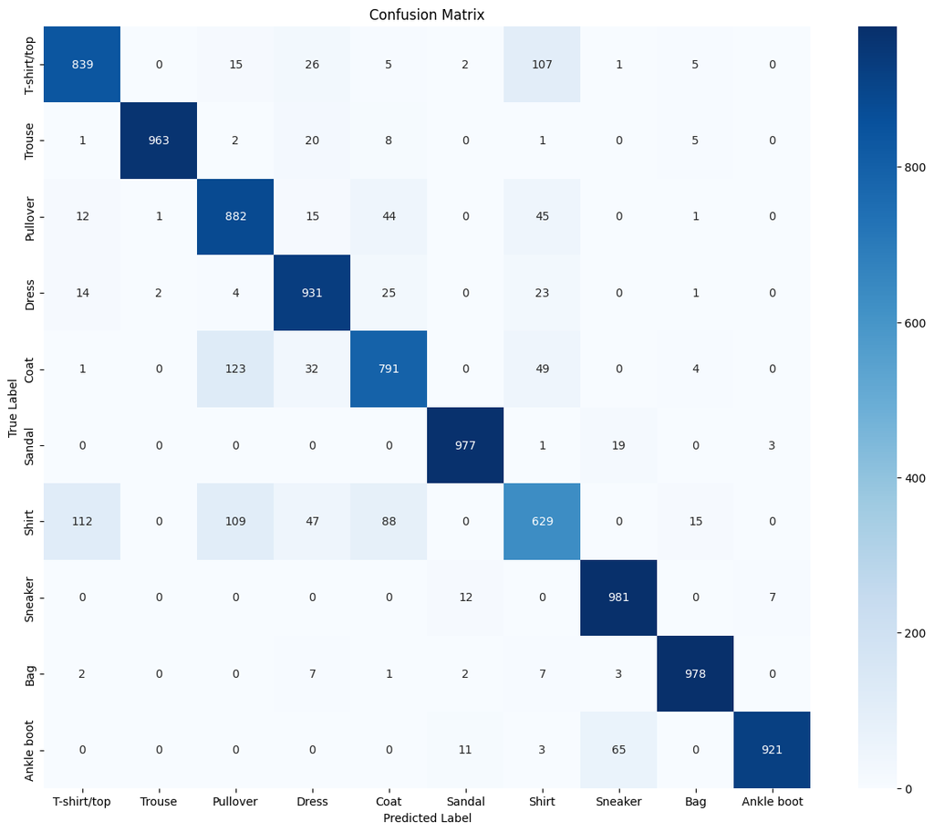

```python
import seaborn as sns
import matplotlib.pyplot as plt

plt.figure(figsize=(15,12))
sns.heatmap(conf_matrix, annot=True, fmt='d', cmap='Blues', xticklabels=class_names, yticklabels=class_names) # fmt='d' > formating numbers/integers inside the heatmap
plt.xlabel('Predicted Label')
plt.ylabel('True Label')
plt.title('Confusion Matrix')
plt.show()
```

### 7. Make a function to show an image of a certain class of the fashion MNIST dataset and make a prediction on it.

For example, plot 3 images of the `T-shirt` class with their predictions.

So we'll create a function, that allows to take the variables: Model, Test_data_images, True_labels, Class_names, Class_category, Number_of_images

```python
# create function to display image of certain class
import random

def plot_class_images(model, images, true_labels, class_names, class_category, num_images):

    # select only the specified class_category
    category_index = class_names.index(class_category) # get index value of class_category
    category_image = images[true_labels == category_index] # only keep the images with the specified category

    # Select random images from the filtered category
    random_indices = np.random.choice(len(category_image), num_images, replace=False)
    selected_images = category_image[random_indices] # select images from the random_indices

    # Reshape images to fit the model input (batch_size, 28, 28, 1)
    selected_images = selected_images.reshape(-1, 28, 28, 1)

    # Make predictions
    pred_probs = model.predict(selected_images)
    pred_labels = [class_names[i] for i in pred_probs.argmax(axis=1)]

    # Plot the images with their predictions
    plt.figure(figsize=(num_images * 5, 5))

    for i in range(num_images):
        plt.subplot(1, num_images, i + 1)
        plt.imshow(selected_images[i].reshape(28,28), cmap=plt.cm.binary)
        true_label = class_category
        pred_label = pred_labels[i]
        confidence = 100 * np.max(pred_probs[i])

        # Set title colour based on correctness
        color = 'green' if pred_label == true_label else 'red'

        plt.xlabel(f'Pred: {pred_label} ({confidence:.0f}%)\nTrue: {true_label}', color=color)
        plt.xticks([])
        plt.yticks([])

    plt.show()
```

```python
# plot 3 tshirts from the function above
plot_class_images(model=model_14, images=test_data, true_labels=test_labels, class_names=class_names, class_category='T-shirt/top', num_images=3)
```

[output not shown]

I've been having trouble just trying to fix the model trying to predict the selected randomized images of the `T-shirt` category.

I think I'll just skip this last exercise, and move on.

```python
pip install nbconvert PyPDF2
```